# 第三章：数据可视化 1: ggplot2

章节作者：刘贇喆 | 华东师范大学 社会发展学院

更新时间：2026-03-19

章节概述

本章以 `ggplot2` 为核心框架，系统梳理数据可视化的基础机制：通过**映射**与**几何对象**将变量编码为图形要素，并在此基础上掌握常用**标度**、**图例**与**主题**设置，形成可复用的图形构建流程（grammar of graphics）。

在实践层面，本章围绕 *9 类*高频统计图形构建可迁移的“图形工具箱”：**散点图**、**折线图**、**柱状图**、**直方图**、**雷达图**、**箱线图**、**流向图**、**山峦图**与**热力图**。各图形均结合典型应用场景，提供可直接复现的绘图语法与简要的读图要点，用于支持对**分布**、**差异**、**关系**与**结构路径**的分析表达。

在方法与规范层面，本章归纳学术制图的关键要求，包括**图形—数据匹配**、*可比性与尺度一致*、**单位与标注完整性**、以及**图例与版式管理**等；并在规范基础上讨论配色与视觉层级优化，用于提升图形的可读性与发表适配性。

# **本章学习内容**

## **学习导航**

**本章学习内容**

欢迎开始 **第 3 章** 的学习。请点击 **下方导航卡** 进入相应小节：

可视化导论

研究证据表达

语法框架

ggplot2基本语法

常用图形

分布/关系/趋势

制图规范

颜色/轴/注释

制图优化

配色与美化

章节练习

复现与挑战

💡 **提示**：学习完一个小节后，请再次点击 **屏幕右下角的**章节主页**按钮**回到本导航页

## **1.0 可视化导论**

### **1.0 数据可视化导论**

基本概念

数据可视化 (Data Visualisation) 是指将抽象的**数据**按照明确的编码规则转换为可读的**图形表达**：通过位置、长度、颜色、形状等视觉通道来映射变量取值，从而呈现数据的分布、结构与关系。

在学术与实证研究语境中，可视化不仅是结果呈现的手段，更是**认知数据**的核心工具。它强调可解释性与证据力：读者应能依据图形元素准确还原变量含义、测量尺度与研究口径，而非仅仅被视觉效果所吸引。

> 可视化的本质是将**数值信息**压缩为**视觉模式**，以提升信息传达。

#### **1.1 为什么要进行数据可视化？**

在量化研究的全流程中，**数据可视化**通常承担着**三个**不可替代的核心职能：

**1. 探索与诊断** (Exploration & Diagnosis)

在正式建立统计模型前，可视化是检验数据质量与揭示潜在特征的首要步骤。单纯的汇总统计量 (如均值、方差、相关系数) 往往会掩盖数据的真实结构 (如经典的安斯库姆四重奏，Anscombe’s quartet)，而图形能够直观且客观地暴露数据的全貌。

- **分布形态检验**：  
  直观评估数据是否符合特定分布 (如正态分布)，以及是否存在偏态 (Skewness) 或多峰 (Multimodal) 结构。
- **异常与噪声识别**：  
  快速定位数据记录中的离群值 (Outliers)、异常的缺失值聚集或潜在的底层编码错误。
- **潜在模式发现**：  
  捕捉变量间复杂的非线性关联、异方差性规律或样本的自然聚类特征。

#### **经典案例：安斯库姆四重奏 (Anscombe’s quartet)**

> **“数值计算是精确的，而图形展示是粗略的。”**

1973年，统计学家 **Frank Anscombe** 针对当时学术界这一**普遍存在的偏见**，构建了四组特殊的数据集进行**反驳**。他指出:

> **若脱离了可视化审视，单纯依赖统计指标往往会得出具有误导性的结论**。

从**基础统计摘要**的维度审视，这四组数据几乎不可区分：

- 相同的**均值** $(\bar{x} = 9, \bar{y} = 7.5)$
- 相同的**方差** $(\sigma_x^2 = 11, \sigma_y^2 \approx 4.125)$
- 相同的**相关系数** $(r \approx 0.816)$
- 甚至拥有相同的**线性回归方程** $(y = 3 + 0.5x)$

然而，当我们引入**可视化视角**时，数据的真实结构差异便一目了然：

[figure not shown]

Figure 3.1. 经典：安斯库姆四重奏

Dataset I：符合线性假设的常规分布。  
Dataset II：呈现明显的**非线性**（曲线）关系，线性模型完全失效。  
Dataset III：整体呈线性，但受**单点离群值**影响，回归参数发生了偏移。  
Dataset IV：**虚假相关**，两者本无线性关系，因一个极端值导致相关系数虚高。

这一案例证明了：

> **统计摘要可能会掩盖数据的本质特征，而可视化则是检验假设、发现异常模式不可或缺的手段。**

**2. 解释与推断** （Interpretation & Inference）

在统计建模与数据分析阶段，可视化不仅用于验证理论假设，还能将抽象的模型结果转化为直观的逻辑链条，辅助研究者进行科学推断。

- **效应比较**：  
  直观呈现不同组别 （如控制组与实验组、不同分类维度） 间的统计差异、效应量 （Effect Size） 及其作用方向。
- **动态与趋势**：  
  揭示时间序列或纵向数据 （Longitudinal Data） 的演变规律，精准定位发展趋势、结构性拐点 （Turning Points） 与周期性特征。
- **不确定性量化**：  
  借助误差棒 （Error Bars） 或置信区间带 （Confidence Bands），图形化呈现参数估计的统计显著性、不确定性及模型预测的稳定性。

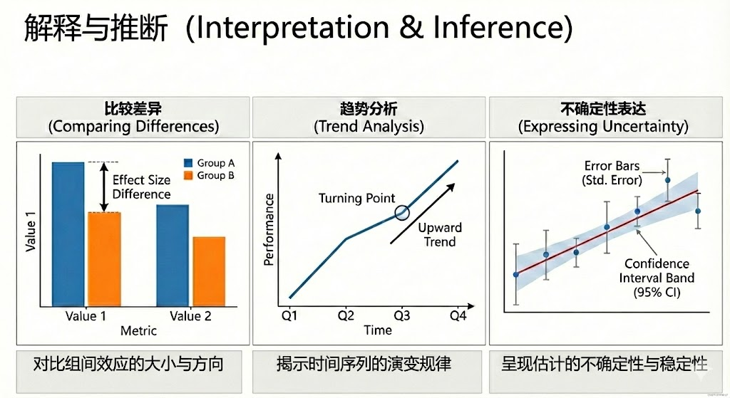

Figure 3.2. 数据可视化 - 解释与推断

**3. 沟通与传播** （Communication & Dissemination）

在学术出版与会议报告中，高质量的图表是提升信息传递效率的核心媒介。优秀的可视化能够有效降低读者的认知负荷 （Cognitive Load），将高度抽象的统计模型推断转化为直观且具说服力的实证研究证据，进而增强学术论证的清晰度与整体影响力。

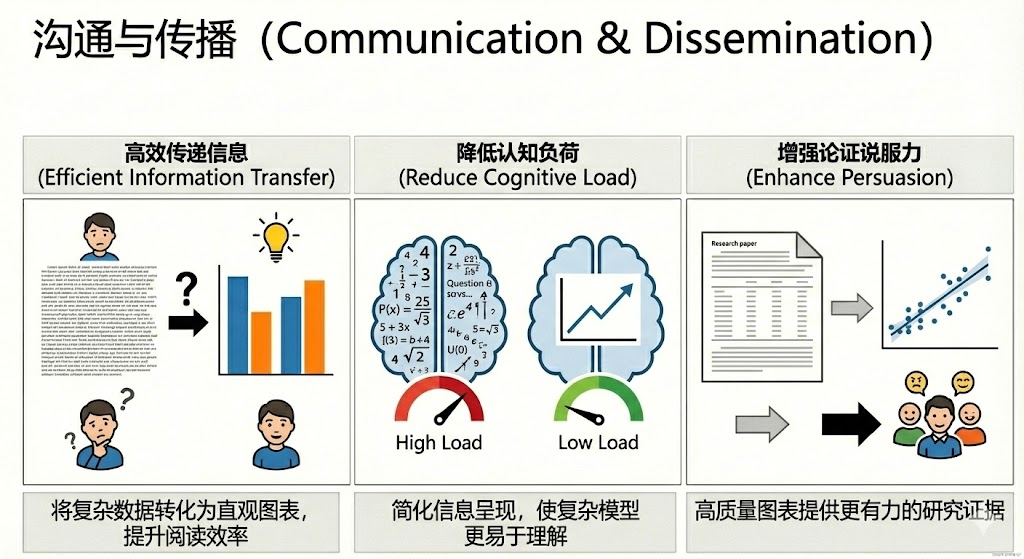

Figure 3.3. 数据可视化 - 沟通与传播

#### **1.2 学术制图的基本原则**

重点

学术图表**不同于商业报表或艺术设计**，其首要目标是遵循**“信、达、雅”**的表达规范，以确保视觉呈现准确、高效且不具误导性。

**1. 诚实原则** （Integrity） —— **“信”**

图形必须忠实反映数据特征，严禁通过视觉偏差扭曲客观事实。

- **坐标基准规范**：  
  条形图的纵轴通常要从 0 开始，慎用截断坐标轴 （Truncated Axis），以防人为夸大数值差异。
- **呈现不确定性**：  
  点估计 （如均值） 无法反映数据全貌。在学术制图中，通常需附带误差棒、置信区间或原始数据分布，以明确统计推断的精确度。
- **比较尺度统一**：  
  进行多组数据对比时，应保持坐标轴范围 （Scale） 一致，确保跨图表间具有科学的可比性。

**2. 自明原则** （Self-Explanatory） —— **“达”**

图表应具备独立表意的能力，确保读者即使脱离正文，也能准确获取核心信息。

- **要素完备**：  
  标题、坐标轴标签、单位与图例需完整且清晰。若数据经过特定转换 （如对数变换，Log Scale），必须在轴标签或图注中明确说明。
- **直观引导**：  
  建议善用文本注释 （Annotation） 直接标示关键数据点或趋势转折，从而降低读者在图例与图形间反复对照的认知负担。
- **信息普适性**：  
  需兼顾灰度打印效果与色盲友好性 （Color-blind Safe），确保视觉信息能准确传达给各类受众。

**3. 极简原则** （Simplicity） —— **“雅”**

学术图表的美学建立在克制与高效之上，其核心是提升 Edward Tufte 提出的**数据-墨水比** （Data-Ink Ratio）。

> 核心理念：图形中的每一滴墨水都应服务于数据表达。
- **剔除图表垃圾**：  
  摒弃无信息量的 3D 特效、阴影、繁杂背景或装饰性元素 （Chartjunk）。
- **优化信噪比**：  
  最大化信号 （数据规律） 的展现，弱化或移除噪音 （如过粗的网格线、冗余的刻度线）。
- **色彩克制**：  
  色彩应用于传递数据映射或区分变量，而非纯粹的视觉装饰；应避免滥用高饱和度的“彩虹色谱”。

#### **1.3 工具引入：为何选择 `ggplot2`？**

在 R 语言的生态中，**Base R** （基础绘图系统） 虽然功能完备，但其采用的是指令式绘图逻辑，即类似“纸笔作画”，不同图形间的语法一致性较弱，且后期修改底层元素较为繁琐。为建立可迁移与可复用的可视化范式，本教程将采用 **`ggplot2`** 作为核心制图工具。

`ggplot2` 的理论内核源自 Leland Wilkinson 的《图形语法》 （The Grammar of Graphics）。该包打破了传统“画点、画线”的机械操作，将数据可视化抽象为一套**可组合的图层构建系统**。它要求使用者明确数据 （Data）、美学映射 （Aesthetics）、几何对象 （Geometries） 与统计变换 （Statistics） 之间的逻辑关系，进而逐层构建图表。

在学术制图中使用 `ggplot2` 的核心优势体现在：

- **语法统一**：  
  无论是基础的散点图、条形图，还是复杂的多面板统计图，均遵循同一套底层语法，极大地降低了学习成本并提升了代码的可扩展性。
- **图层叠加**：  
  以图层 （Layer） 为基本运算单元，支持将坐标系、几何图形、注释等元素逐一叠加 （通过 `+` 符号连接），使得图形的精细微调与迭代优化更加直观。
- **高度定制**：  
  内置成熟的标度 （Scale） 与主题 （Theme） 系统，能够精确控制坐标轴、图例、字体及色彩，轻松输出符合学术期刊规范的印刷级图表。
- **生态融合**：  
  作为 `tidyverse` 的核心组件之一，`ggplot2` 与 `dplyr`、`tidyr` 等数据处理工具无缝衔接。在实际工作流中，通常仅需执行 `library(tidyverse)` 即可完成加载，实现从数据清洗到可视化的流畅闭环。

[figure not shown]

Figure 3.4. ggplot2 可视化工具与优势

#### **ggplot2 绘图能力预览**

`ggplot2` 的强大之处在于其**通用性**。无论是基础统计图，还是复杂的地理空间图或多维分面图，遵循的都是同一套图层语法。以下是使用该包绘制的一些典型案例：

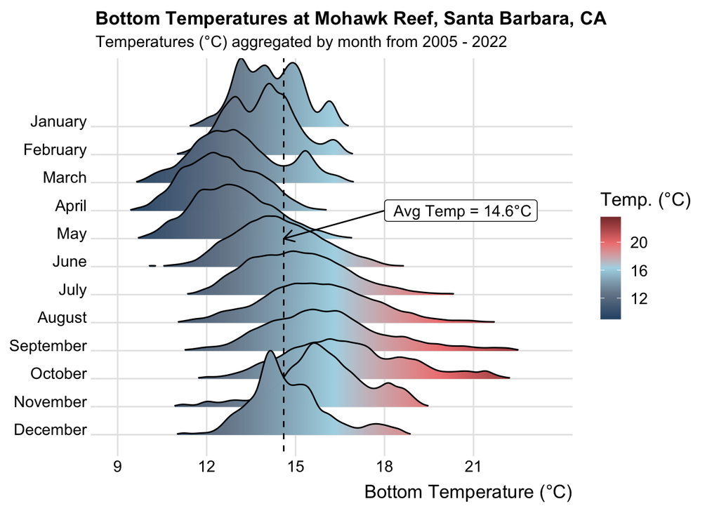

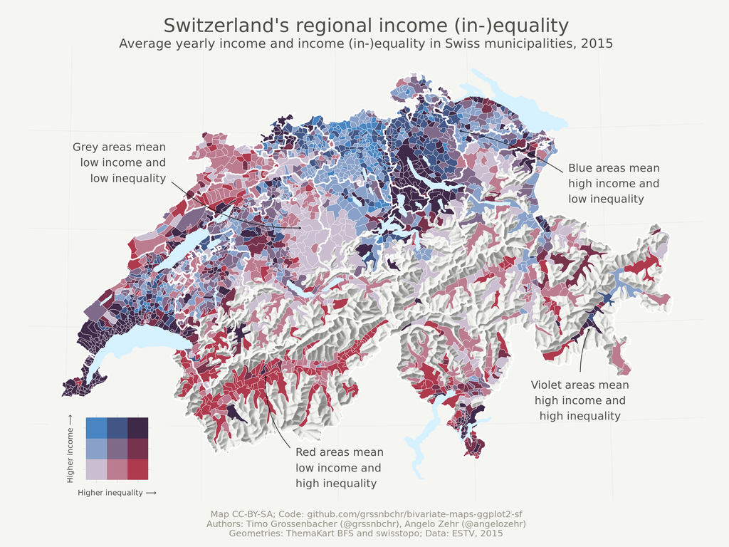

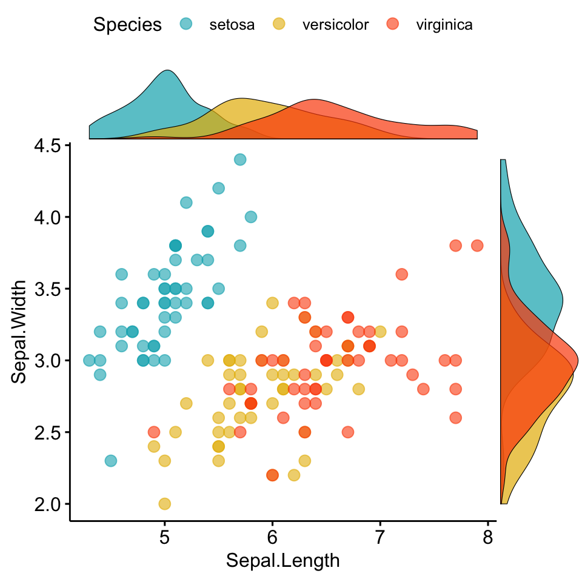

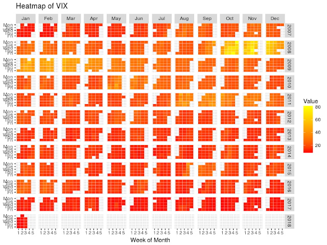

Figure 3.5. ggplot2 多样化绘图示例

## **2.0 ggplot2 语法框架**

### **2.0 ggplot2图形语法**

工具基础

**`ggplot2`** 是 R 语言中最具影响力的可视化工具包，其命名源自统计学家 **Leland Wilkinson** 的经典著作 **《图形语法》** (The Grammar of Graphics)。与 Excel 或 Base R 这种“预设图表类型” (如：选择‘柱状图’或‘饼图’) 的绘图逻辑不同，`ggplot2` 采用了一套**构建式**的逻辑 (见Fig3.6)：

它认为任何统计图形都可以拆解为一组独立的组件 (Components)：**数据**、**坐标系**、**几何对象**与**统计变换**。用户通过将这些组件像“图层”一样叠加，即可构建出无限可能的图形组合。

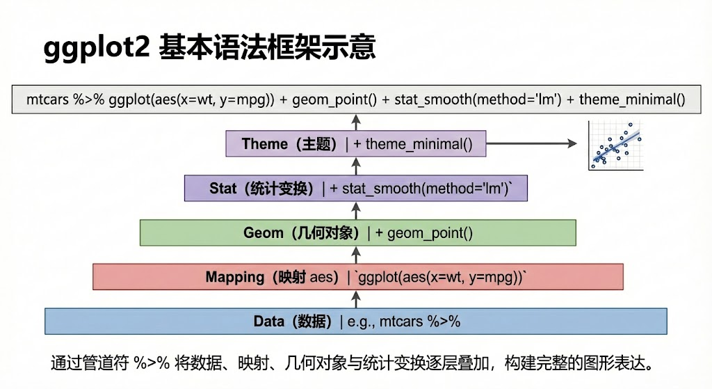

Figure 3.6. ggplot2 基本语法示意图

在开始绘制之前，请确保已正确加载了核心工具包：

#### **环境检查：加载 Tidyverse**

注意

`ggplot2` 是 `tidyverse` 生态系统的核心组件。在开始本章练习前，请确认当前 R 会话中已加载该包：

```r
# 推荐：一次性加载 tidyverse 全家桶（包含 ggplot2）
library(tidyverse)

# 或者：仅加载 ggplot2
# library(ggplot2)
```

#### **2.1 ggplot2 核心逻辑**

理解 `ggplot2` 的关键在于掌握其“分层”（Layered）语法结构。

> 一张统计图形，本质上是由若干核心要素通过加号 `+` 逐层叠加而成。

如 Fig. 3.6 所示，一个标准的绘图语句通常包含以下三个必须要素：

要素1 **数据层**（Data）

> **“画什么？”** 绘图的基础必须是一个**数据框**（data frame / tibble）。

`ggplot2` 通常不以“单独向量”为输入，而是要求数据以整洁数据（Tidy Data）形式组织：每一列是一个变量，每一行是一个观测。

要素2 **映射层**（Aesthetics Mapping）

> **“怎么画？”** 建立**数据变量**与**视觉属性**之间的对应关系。

这种对应关系称为**映射**（mapping），通常写在 `aes()` 中：

- **x / y**：将哪一列映射到 x 轴与 y 轴？
- **color / fill**：类别或数值差异如何通过颜色区分（线色 vs 填充色）？
- **size / shape**：变量差异如何通过点大小或形状体现？
- **alpha**：用透明度表达密度或强调/弱化某些观测（常用于点重叠）。
- **group**：当绘制折线/平滑线时，用于明确“按哪一组连线/拟合”（常见于多组时间序列）。

要素3 **几何对象层**（Geometric Objects）

> **“画成什么样？”** 决定数据在图中呈现的具体形态。

`ggplot2` 中，控制“画成什么样”的函数通常以 `geom_` 开头，例如：

- `geom_point()`：画点（散点图）
- `geom_line()`：画线（折线图）
- `geom_bar()`：画条形（柱状图；常用于类别计数）
- `geom_col()`：画条形（柱状图；y 由数据提供）
- `geom_histogram()`：画直方图（连续变量分布）
- `geom_density()`：画密度曲线（连续变量分布）
- `geom_boxplot()`：画箱线图（组间分布比较）
- `geom_violin()`：画小提琴图（分布形态更直观）
- `geom_smooth()`：画趋势线/拟合线（可带置信区间）
- `geom_errorbar()`：画误差棒（不确定性表达）

#### **2.2 简单案例：使用 `ggplot2` 与 `gapminder`**

基础 · 代码实战

为练习 `ggplot2` 的分层逻辑，本节使用**最小可运行代码**构建一张基础散点图，**暂不涉及主题、配色与图例等美化设置**。目标是基于`gapminder`数据中 `2007` 年数据绘制 `人均 GDP` 与 `预期寿命` 的关系，并用颜色区分大洲

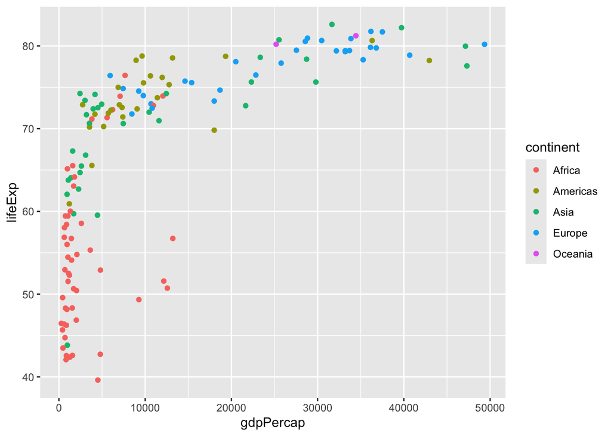

```r
# 0. 准备工作
library(tidyverse)
library(gapminder)

# 筛选 2007 年数据
data_2007 <- gapminder %>%
  filter(year == 2007)

# 1. 基础绘图语句
ggplot(
  data = data_2007,       # 数据源：也可写成 data_2007 %>% ggplot(...)
  mapping = aes(          # mapping = 可省略：直接写 aes(x = ..., y = ...)
    x = gdpPercap,        # x 轴：人均 GDP
    y = lifeExp,          # y 轴：预期寿命
    color = continent     # 颜色映射：按大洲分组
  )
) +
  geom_point()            # 几何层：用“点”呈现观测值
```

逻辑对应

该示例直观地展示了 **2.1 节** 的三个核心要素如何在代码中落地：

- **1. 数据层** （Data）：`ggplot(data = data_2007, ...)`
  - 指定绘图数据来源；`gdpPercap`、`lifeExp` 与 `continent` 均直接读取自该数据框。
- **2. 映射层** （Mapping）：`aes(...)`
  - 定义**变量**到**视觉属性**的映射关系：
  - `gdpPercap` $\rightarrow$ **x** (横坐标)
  - `lifeExp` $\rightarrow$ **y** (纵坐标)
  - `continent` $\rightarrow$ **color** (颜色)
- **3. 几何层** （Geom）：`geom_point()`
  - 指定以“**点**”的形式呈现上述映射后的数据关系（即绘制散点图）。

#### **补充：管道写法**（把 data 放在外面）

在 `tidyverse` 语境中，**data部分** 可以放到 `ggplot()` 外侧，用 `%>%` 把数据“送入”绘图语句，使流程更连贯：

```r
gapminder %>%
  filter(year == 2007) %>%
  ggplot(aes(x = gdpPercap, y = lifeExp, color = continent)) +
  geom_point()
```

#### **2.3 `ggplot2` 实战进阶**

#### **前置准备：解决中文乱码问题**

重要步骤

默认情况下，`ggplot2` 在渲染中文标题或标签时可能会出现**乱码**（显示为方框 `□□`），这是因为系统**默认字体**不支持中文字符。

为了确保图表中的中文能正常显示，我们需要引入 **`showtext`** 包。它可以帮助 R 更好地调用系统字体或加载网络字体。

请在运行绘图代码前，**务必先运行**以下配置代码：

```r
# --- 1. 安装字体扩展包 (仅需运行一次) ---
# install.packages("showtext")

# --- 2. 加载并配置 (每次启动 RStudio 都需运行) ---
library(showtext)

# 自动开启字体支持
showtext_auto()
```

进阶 · 代码实战

为进一步理解 `ggplot2` 的**分层语法**，本节以 `gapminder` 数据集为例，复现 Hans Rosling 经典的“财富与健康”气泡图思路。

我们截取 **2007 年**数据，重点回答三个问题：  
**人均 GDP**（经济发展） 与 **预期寿命**（健康水平） 之间呈现何种关系？不同大洲国家在该关系中的分布差异如何？**人口规模**如何通过气泡大小被编码并辅助解读？

请在 RStudio 中运行下方代码，并对照后续小节逐行理解：每一句分别对应哪一层（数据/映射/几何/标度/主题），以及它如何影响最终图形的呈现。

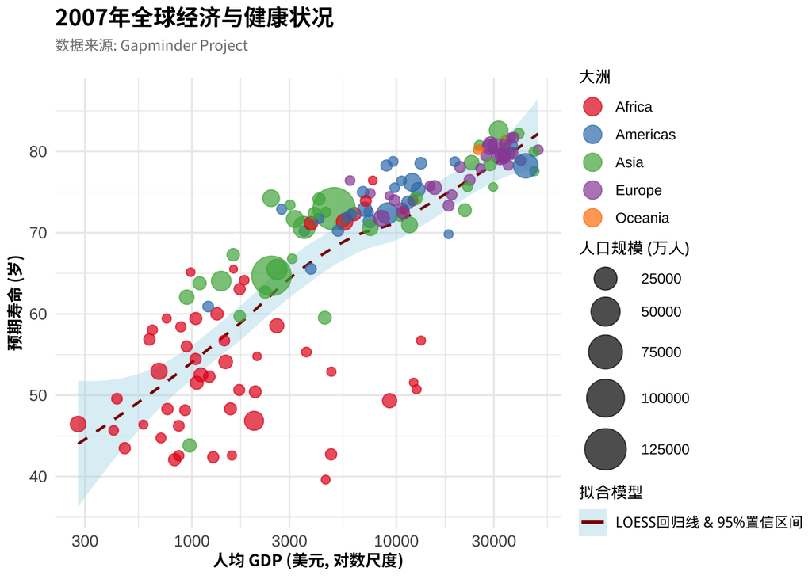

```r
# ==============================================================================
# 0. 环境准备与字体配置
# ==============================================================================
library(tidyverse)  # 核心数据科学包 (包含 ggplot2, dplyr 等)
library(gapminder)  # 演示数据
library(showtext)   # 字体渲染包 (解决中文乱码的关键)

# [字体配置] 注册谷歌在线字体
# 说明：自动下载 "Noto Sans SC" (思源黑体) 并注册名为 "my_font"
# 优势：该方案在 Windows/Mac/Linux 上通用，无需依赖用户本地字库
font_add_google(name = "Noto Sans SC", family = "my_font")

showtext_auto()        # 启用自动字体渲染
options(scipen = 9999) # 调整科学计数法策略，使大数值显示为普通数字

# ==============================================================================
# 1. 数据准备
# ==============================================================================
# 提取 2007 年的横截面数据
data_2007 <- gapminder %>% filter(year == 2007)

# ==============================================================================
# 2. 绘图构建
# ==============================================================================
ggplot(data = data_2007,
       mapping = aes(x = gdpPercap, y = lifeExp)) +

  # --- 图层 A: 统计趋势线 (LOESS 回归) ---
  # 说明：我们在此处手动映射 linetype 和 fill，是为了强制生成一个图例项
  geom_smooth(mapping = aes(linetype = "LOESS回归线 & 95%置信区间",
                            fill = "LOESS回归曲线 & 95%置信区间"),
              method = "loess",      # 使用局部加权回归算法
              se = TRUE,             # 显示置信区间阴影
              color = "darkred",     # 设置线条的物理颜色 (不参与映射)
              linewidth = 0.8) +     # 设置线条粗细

  # --- 图层 B: 散点气泡图 ---
  geom_point(mapping = aes(size = pop/10000,   # 大小映射：人口 (单位：万人)
                           color = continent), # 颜色映射：大洲
             alpha = 0.7,            # 设置点的透明度
             stroke = 0.5) +         # 设置点的描边粗细

  # --- 标度设置 (Scales) ---
  scale_x_log10() +                  # x轴对其进行对数变换，拉开数据间距
  scale_color_brewer(palette = "Set1") + # 使用 Set1 预设色盘

  # 控制气泡面积的视觉范围
  scale_size(range = c(2, 12),
             name = "人口规模 (万人)") +

  # [图例自定义] 定义回归线图例的具体样式
  # values = "dashed" 确保了【图表画布中】的回归线保持为虚线
  scale_linetype_manual(name = "拟合模型", values = "dashed") +
  scale_fill_manual(name = "拟合模型", values = "lightblue") +

  # --- 标签设置 (Labels) ---
  labs(
    title = "2007年全球经济与健康状况",
    subtitle = "数据来源: Gapminder Project",
    x = "人均 GDP (美元, 对数尺度)",
    y = "预期寿命 (岁)",
    color = "大洲"
  ) +

  # --- 图例控制 (Guides) ---
  # 作用：对自动生成的图例进行精细化修饰
  guides(
    # 1. 修改 [颜色/大洲] 图例：在图例中强制放大圆点，便于识别
    color = guide_legend(override.aes = list(size = 5), order = 1),

    # 2. 设定 [大小/人口] 图例的排列顺序
    size = guide_legend(order = 2),

    # 3. 修改 [回归线] 图例：强制覆写图例样式
    # 说明：虽然图中是虚线，但为了图例清晰，强制将其显示为“实线+深红+蓝底”
    linetype = guide_legend(
      order = 3,
      override.aes = list(
        linetype = "solid",    # 图例显示为实线
        color = "darkred",     # 图例线色为深红
        fill = "lightblue",    # 图例填充为浅蓝
        linewidth = 1          # 图例线加粗
      )
    ),

    # 4. 隐藏 [填充] 图例 (已合并至 linetype，无需重复显示)
    fill = "none"
  ) +

  # --- 主题设置 (Theme) ---
  theme_minimal() +
  theme(
    # 字体设置：调用开头注册的 "my_font" (思源黑体)
    plot.title = element_text(family = "my_font", face = "bold", size = 14, hjust = 0),
    plot.subtitle = element_text(family = "my_font", size = 9, color = "grey50", face = "italic", margin = margin(b = 15)),

    # 坐标轴文字
    axis.title = element_text(family = "my_font", face = "bold", size = 10),
    axis.text = element_text(size = 10),

    # 图例布局
    legend.position = "right",
    legend.text = element_text(size = 9),
    legend.title = element_text(size = 10, face = "bold"),
    legend.spacing.y = unit(0.2, "cm"),
    legend.margin = margin(t = 0, b = 0, l = 0, r = 0)
  )
```

#### **2.4 语法拆解：从图层到细节**

深度解析

上一节案例虽然代码较长，但核心仍是 `ggplot2` 的**分层语法**：先确定数据与全局映射，再按功能叠加图层，最后通过标度与主题完成出版级表达。本节按该案例的实际写法，拆解为四个关键维度。

#### **1. 画布与全局映射**

> `ggplot(data = data_2007, mapping = aes(x = gdpPercap, y = lifeExp))`

在最顶层的 `ggplot()` 中，我们只定义 **x/y 的全局映射**，为后续图层提供共同的坐标框架。

- **继承机制**：该映射是全局的，后续 `geom_smooth()` 与 `geom_point()` 默认继承 `x` 与 `y`，无需重复声明。
- **数据准备**：绘图前先用 `filter(year == 2007)` 构造截面数据，避免把不同年份混在同一张图里造成解释偏差。

#### **2. 图层的堆叠顺序**

> `ggplot2` 按代码顺序绘制：先写在下，后写在上
- **底层（Layer 1）**：`geom_smooth(...)`  
  先画 LOESS 趋势线及其 95% 置信区间，使散点气泡覆盖在线条之上，避免线条穿插点形影响读图。
- **顶层（Layer 2）**：`geom_point(...)`  
  点层单独承担“主要信息编码”：
  - `color = continent` 用于大洲分组；
  - `size = pop/10000` 用于人口规模（单位换算为“万人”）。  
    同时趋势线颜色被固定为 `darkred`，与点层的颜色映射相互隔离。  
    （点随数据变，线保持统一样式）

#### **3. 图例的定制**

该案例的图例设计有两个目标：**该出现的必须出现**，**出现后的必须可读**。

**A. 图例项的“人为生成”**  
在 `geom_smooth()` 中使用：

`aes(linetype = "LOESS回归线 & 95%置信区间", fill = "LOESS回归曲线 & 95%置信区间")`

- **原理**：在 `aes()` 中写入字符串，相当于构造一个“伪分类变量”，从而强制 `ggplot2` 生成对应图例项。
- **配合**：通过
  - `scale_linetype_manual(name = "拟合模型", values = "dashed")`
  - `scale_fill_manual(name = "拟合模型", values = "lightblue")`  
    明确指定线型与置信区间填充的视觉样式，并统一图例标题为“拟合模型”。

**B. 覆写图例样式**（`guides` & `override.aes`）  
默认图例会复刻图中元素，但在信息密集图里往往不够清晰，因此使用 `override.aes` 做“图例可读性优化”：

- **大洲颜色图例**：`override.aes = list(size = 5)` 强制放大图例圆点，提升颜色辨识度。
- **拟合模型图例**：尽管图中回归线为虚线，为避免图例线段破碎难辨，使用  
  `override.aes = list(linetype = "solid", color = "darkred", fill = "lightblue", linewidth = 1)`  
  让图例更易读。
- **去重**：`fill = "none"` 隐藏填充图例，避免与 linetype 图例重复呈现。

#### **4. 标度与主题的精修**

细节

- **对数坐标（信息展开）**：`scale_x_log10()` 用于处理 GDP 的**右偏**分布，减少尺度压缩，使低—中收入区间的点位差异更可见。
- **颜色标度（稳定可复用）**：`scale_color_brewer(palette = "Set1")` 提供一致的离散配色方案，便于跨图复现。
- **大小标度（控制视觉范围）**：`scale_size(range = c(2, 12), name = "人口规模 (万人)")`  
  统一气泡面积的可视范围，同时明确单位口径。
- **字体与排版（出版一致性）**：通过 `showtext + font_add_google()` 注册并调用 `family = "my_font"`，保证标题、轴标签与图例文本在不同系统下保持一致渲染；其余字号、加粗、边距等由 `theme()` 集中管理。

#### **总结：本案例的三条操作准则**

1. **先全局、后局部**：先在 `ggplot()` 里定义 `x/y`，再在各 `geom_` 层补充该层独有的映射与设置。
2. **映射 vs 设置**：随数据变化写进 `aes()`；固定样式写在 `aes()` 外（如回归线 `color = "darkred"`）。
3. **图例来自映射**：图例由 `scale` 与 `guides` 驱动；想控制图例，优先改 `scale_*()`，再用 `override.aes` 提升可读性。

## **3.0 常用图形**

### **3.0 常用图形出图**

#### **3.0 常用图形工具箱**

##### **图形导航**

**ggplot2 可视化图谱**

**“一图胜千言”**。本章精选了学术与商业分析中最高频使用的 9 种统计图形。  
点击下方卡片，快速跳转至对应图形的绘制语法、应用场景与美化技巧。

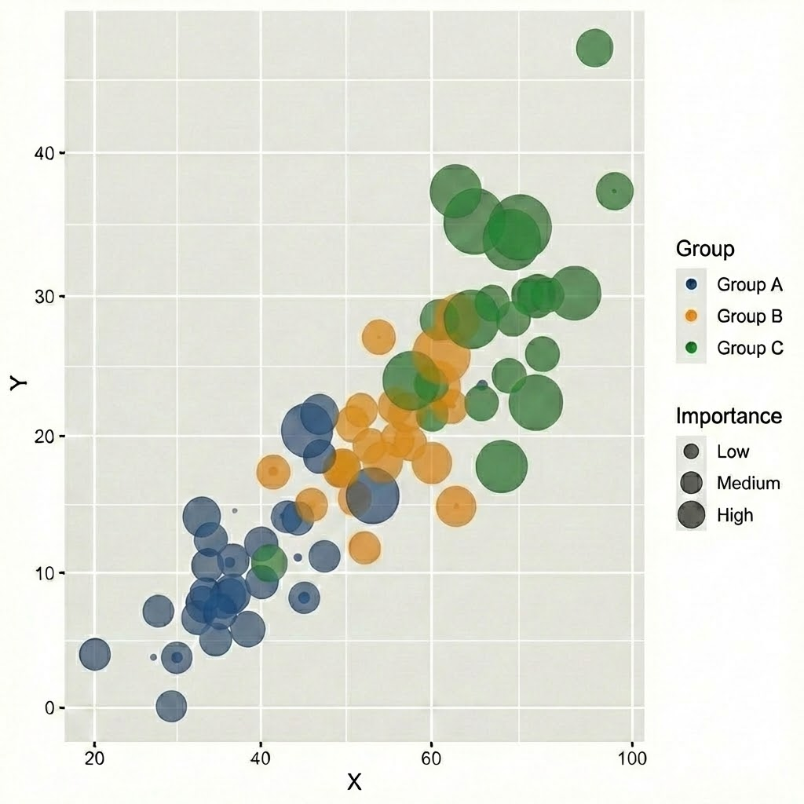

3.1 散点图

geom_point | 相关性

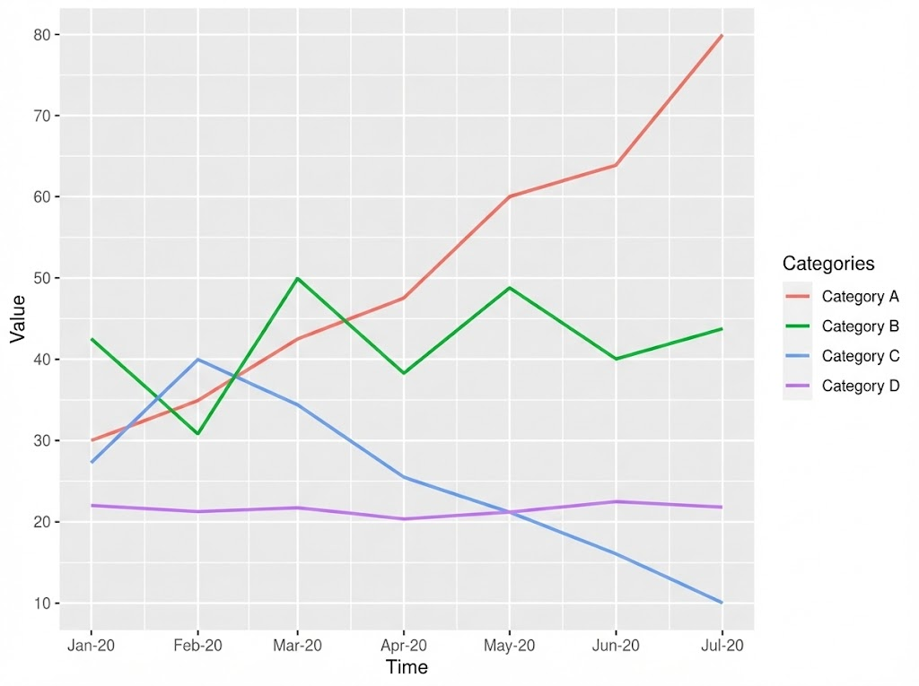

3.2 折线图

geom_line | 时间序列

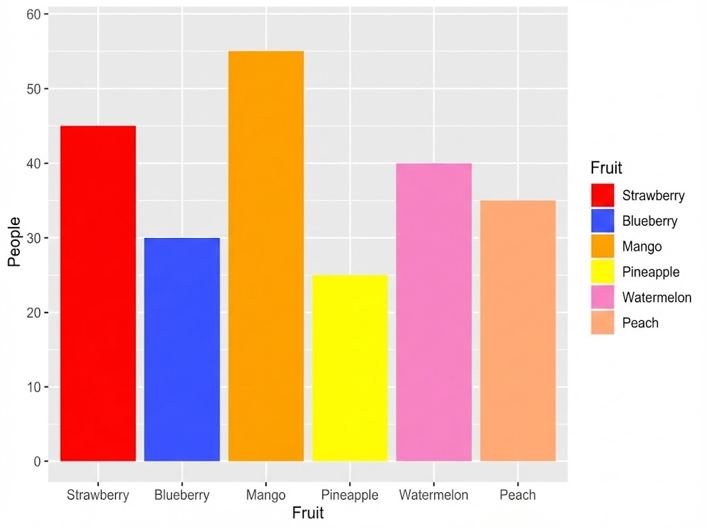

3.3 柱状图

geom_col / bar | 类别比较

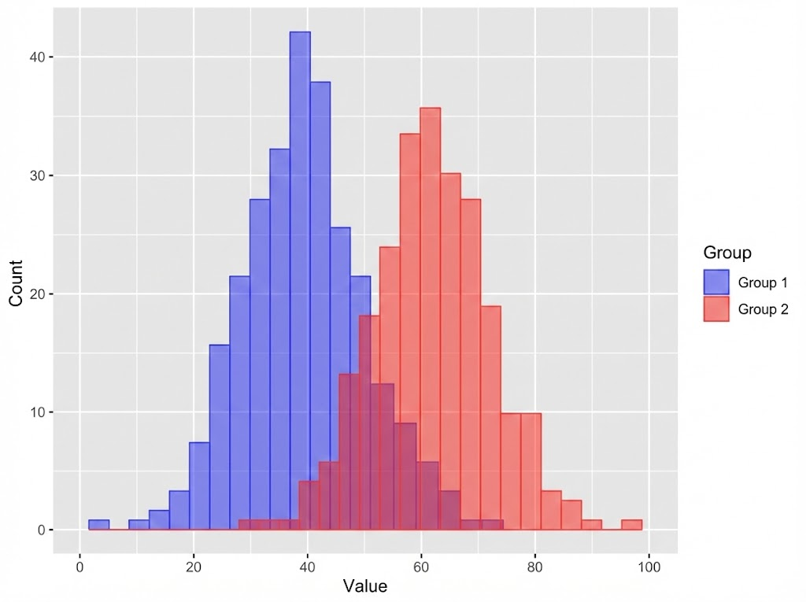

3.4 直方图

geom_histogram | 频数分布

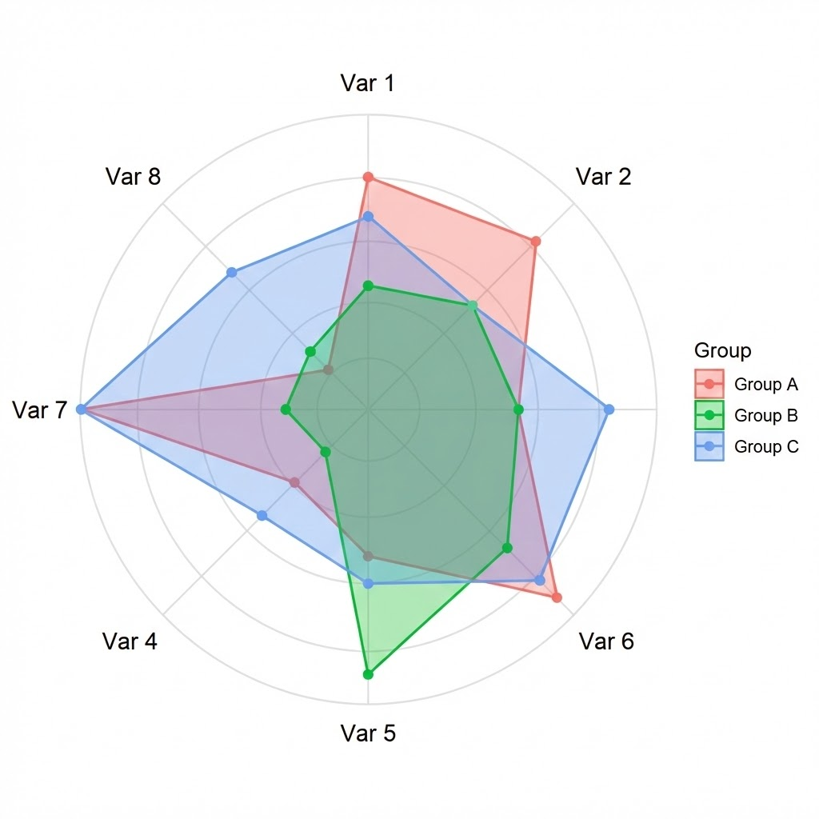

3.5 雷达图

ggradar插件 | 多维比较

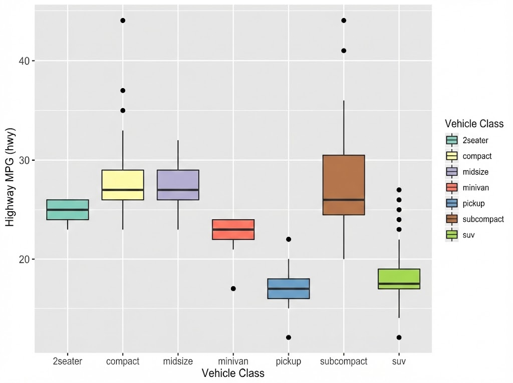

3.6 箱线图

geom_boxplot | 离群值

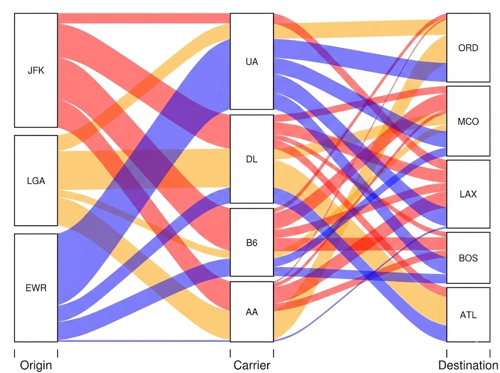

3.7 流向图

ggalluvial | 流向与迁移

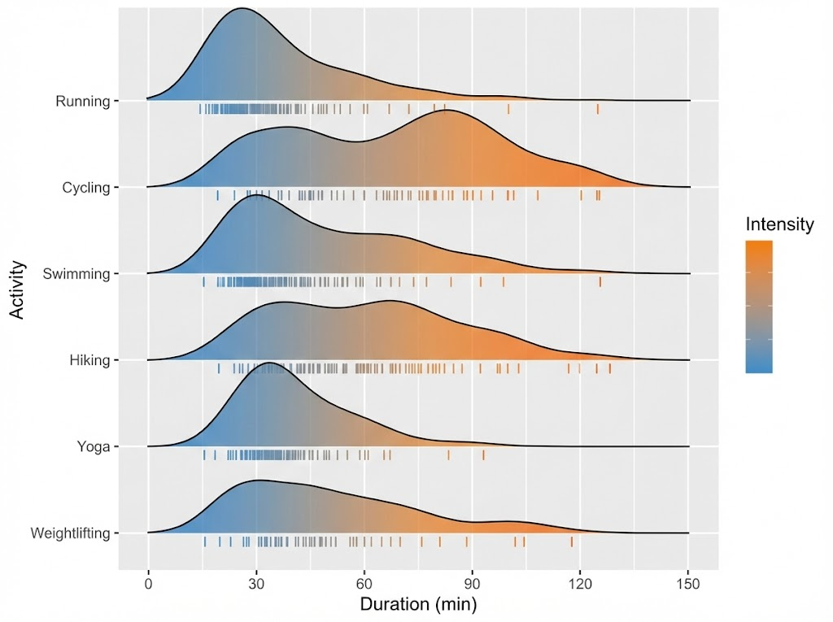

3.8 山峦图

ggridges | 脊线与层叠

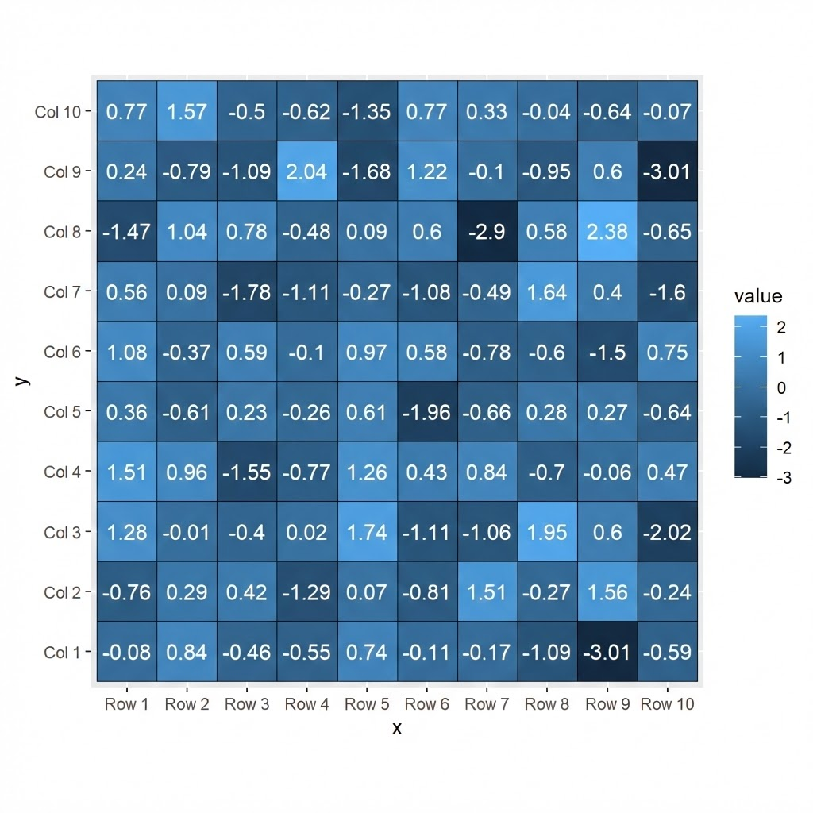

3.9 热力图

geom_tile | 矩阵可视化

💡 **学习建议**：所有的几何对象 (`geom_*`) 都遵循相同的语法逻辑。  
掌握前三种基础图形后，其余图形只需更换函数名即可融会贯通。

##### 散点图

###### **3.1 散点图：相关性**

基础 · 图形概念

**散点图**（Scatter Plot）用于探索**两个连续变量**之间的关系。它将每条观测映射到二维坐标系中，通过点的空间分布呈现变量间的共变模式、分层结构与异常观测。

**1. 核心用途**

- **相关性探索**：  
  观察两变量是否呈现正相关、负相关或弱相关关系。  
  （例如：人均 GDP 上升时，预期寿命是否同步上升？）
- **结构识别**：  
  判断数据是否存在自然分组或聚集现象。  
  （Clusters）
- **离群值发现**：  
  识别远离主要分布区域的异常观测。  
  （Outliers）

**2. 核心函数**

在 `ggplot2` 中，散点图对应的几何对象函数为：

> **`geom_point()`**

基础 · 实战代码

本节继续使用 `gapminder` 数据集，并选取 **2007 年** 的截面数据，绘制 **人均 GDP** 与 **预期寿命** 的散点图。每个点代表一个国家或地区，用于直观观察两变量之间的分布关系。

**代码逻辑**：

Step 1 **加载数据与绘图环境**  
导入 `tidyverse` 与 `gapminder`，用于数据筛选与 `ggplot2` 绘图。

Step 2 **构建横截面样本（2007 年）**  
使用 `filter(year == 2007)` 提取单一年份数据，避免不同时期混合导致关系被“时间趋势”干扰。  
（横截面图更适合做变量关系的直观初判）

Step 3 **建立映射关系（x–y–分组颜色）**  
将 `gdpPercap` 映射到 `x`、`lifeExp` 映射到 `y`，并将 `continent` 映射到 `color`：  
- `x` 与 `y` 给出两个连续变量的二维位置关系；  
- `color` 用于区分大洲，便于比较不同区域的分布层次与聚集模式。

Step 4 **绘制散点并补全图形信息**  
使用 `geom_point()` 绘制国家点位；再通过 `labs()` 明确标题、坐标轴含义与图例名称，最后用 `theme_minimal()` 降低背景干扰，突出数据结构。

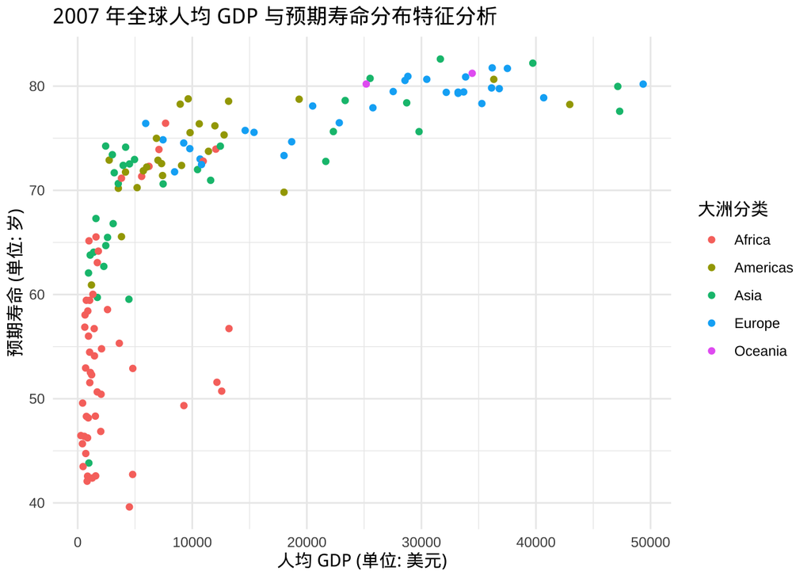

```r
library(tidyverse)
library(gapminder)
library(showtext)
showtext.auto()
# 1. 数据预处理：提取 2007 年度全球跨国横截面观测样本 (Cross-sectional Data)
data_scatter <- gapminder %>%
  filter(year == 2007)

# 2. 视觉映射与统计逻辑：基于经济水平与健康产出维度的关联性分析
ggplot(
  data = data_scatter,
  mapping = aes(
    x = gdpPercap,    # 解释变量 (Independent Variable): 人均 GDP
    y = lifeExp,      # 响应变量 (Dependent Variable): 预期寿命
    color = continent # 类别变量映射：大洲分类属性
  )
) +
  # 3. 几何图层：利用散点特征揭示双变量间的相关性趋势及样本离散分布状态
  geom_point() +

  # 4. 语义标注与视觉排版净化
  labs(
    title = "2007 年全球人均 GDP 与预期寿命分布特征分析",
    x     = "人均 GDP (单位: 美元)",
    y     = "预期寿命 (单位: 岁)",
    color = "大洲分类"
  ) +

  theme_minimal() # 采用极简设计原则，通过提升“数据墨水比”聚焦核心统计关联
```

#### **图形解读：怎么读这张散点图？**

**读图方法**

- **看坐标含义**：  
  横轴是人均 GDP，纵轴是预期寿命；每个**点**代表一个国家或地区。
- **看点云走向**：  
  点整体从**左下向右上**延展，说明两变量存在同向变化（说明：GDP 更高的国家往往寿命更长）。
- **看分布形态与异常点**：  
  关注点云是否集中在某些区域、是否出现少量远离主体的点，这些通常提示结构差异或特殊国家或地区。

**从图中可直接读出的主要信息**

- **总体格局**：  
  国家层面的人均 GDP 与预期寿命呈明显正相关。
- **“高收入区间”变化趋缓**：  
  在图的右侧区域，点在纵向（寿命）上的提升幅度相对有限，体现出寿命随 GDP 增长的边际收益递减特征。
- **离散度差异**：  
  在中低 GDP 区间，寿命分布更分散；而在较高 GDP 区间，寿命更集中，国家间差异相对收敛。

进阶 · 实战代码

本节在同一张散点图中同时呈现**变量关系**、**拟合结果**与**跨期对比**：以 `log10(gdpPercap)` 为横轴、`lifeExp` 为纵轴，叠加线性回归拟合与置信区间，并在每个年份分面内标注回归方程与 Pearson 相关系数。

**代码逻辑**：

Step 1 **数据筛选与变量变换**  
从 `gapminder` 中筛选 `1952 / 1977 / 2007` 三个年份，并构造三类派生变量：  
- `year` 转为因子（用于分面）  
- `log_gdp = log10(gdpPercap)`（压缩经济量级跨度，提升可读性与拟合稳定性）  
- `pop_wan = pop / 10000`（人口单位换算为“万人”，用于点大小映射）

Step 2 **分年统计：回归系数 + 相关系数 + 注释位置**  
按 `year` 分组计算每个分面的统计量：  
- 线性模型 `lifeExp ~ log_gdp` 的系数 `b0, b1`（用于可读化方程文本）  
- Pearson 相关系数 `r` 与样本量 `n`（用于描述线性相关强度与信息量）  
同时基于该分面的数据范围生成 `x_pos, y_pos`，使标注在不同分面中都能稳定落在画布内、避免越界。

Step 3 **构建图层：拟合带 + 气泡散点 + 分面标注**  
在 `ggplot(log_gdp, lifeExp)` 的基础上叠加三类核心图层：  
- `geom_smooth(method = "lm", se = TRUE)`：绘制回归线与 95% 置信区间；并通过映射 `linetype/fill` 人为生成“拟合模型”图例项（便于读图说明）  
- `geom_point(aes(color = continent, size = pop_wan))`：绘制国家散点，颜色区分大洲、点大小编码人口规模  
- `facet_wrap(~ year, ncol = 1)`：按年份纵向排列，保证跨期对照结构清晰  
- `geom_text(data = stats_year, ...)`：将“方程 + r + n”写入每个分面，形成可直接阅读的统计摘要

Step 4 **标度与图例组织（保证信息不重复）**  
分别设置三类标度：  
- `scale_color_brewer()`：大洲配色  
- `scale_size()`：人口大小范围与图例标题  
- `scale_linetype_manual()` 与 `scale_fill_manual()`：统一“拟合模型”图例命名，并在 `guides()` 中将 `fill` 合并到 `linetype` 图例，避免重复出现两个模型图例。

Step 5 **版式与字体：统一学术排版风格**  
使用 `theme_minimal()` 并在 `theme()` 中统一设置 `my_font`，同时规范标题层级、图例文字与间距，以保证跨图一致性与出版友好。

[figure not shown]

```r
# =============================================================
# 综合可视化：全球经济水平与预期寿命的跨时域关联分析
# 技术要点：对数变换、OLS 回归、组内统计量推导、分面布局优化
# =============================================================

library(tidyverse)
library(gapminder)
library(showtext)

# 1. 绘图环境配置与字体初始化
font_add_google(name = "Noto Sans SC", family = "my_font")
showtext_auto()
options(scipen = 9999) # 禁用科学计数法，确保坐标轴标注的规范性

# 2. 数据处理与特征工程：样本筛选、对数变换与量级归一化
data_adv <- gapminder %>%
  filter(year %in% c(1952, 1977, 2007)) %>%
  mutate(
    year    = factor(year),      # 离散化年份变量，作为分面依据
    log_gdp = log10(gdpPercap),   # 对数变换 (base 10)：压缩长尾分布，构建线性关联基础
    pop_wan = pop / 10000         # 归一化处理：将人口单位转化为“万人”，优化气泡大小映射
  )

# 3. 组内统计推断：计算相关系数、回归系数与动态标注坐标
# 目标：为每个分面生成独立的描述性统计量与方程文本
stats_year <- data_adv %>%
  group_by(year) %>%
  summarise(
    n  = n(),
    r  = cor(log_gdp, lifeExp, method = "pearson", use = "complete.obs"), # Pearson $r$
    b0 = coef(lm(lifeExp ~ log_gdp))[1], # 截距 $\beta_0$
    b1 = coef(lm(lifeExp ~ log_gdp))[2], # 斜率 $\beta_1$

    # 启发式坐标计算：根据各分面数据极值动态生成标注位置，防止文字重叠与越界
    x_pos = min(log_gdp, na.rm = TRUE) + 0.03 * diff(range(log_gdp, na.rm = TRUE)),
    y_pos = max(lifeExp, na.rm = TRUE) - 0.05 * diff(range(lifeExp, na.rm = TRUE)),
    .groups = "drop"
  ) %>%
  mutate(
    label = paste0(
      "拟合模型： $y$ = ", round(b0, 2), " + ", round(b1, 2), "$x$\n",
      "Pearson $r$ = ", round(r, 2), " (n = ", n, ")"
    )
  )

# 4. 可视化构建：层级化图形呈现
ggplot(data_adv, aes(x = log_gdp, y = lifeExp)) +

  # 图层 A：统计推断层 (OLS Regression)
  # 通过人为映射 linetype 与 fill 构建统一的模型统计量图例
  geom_smooth(
    aes(
      linetype = "线性回归线（lm）",
      fill     = "95% 置信区间"
    ),
    method = "lm",
    se = TRUE,
    color = "darkred",
    linewidth = 0.8
  ) +

  # 图层 B：原始观测值层 (Bubble Plot)
  # 实施多维度美学映射：颜色 (大洲类别) 与 面积 (人口规模)
  geom_point(
    aes(color = continent, size = pop_wan),
    alpha  = 0.35,
    stroke = 0.25
  ) +

  # 图层 C：空间分解层 (Faceting)
  # 沿时间维度进行纵向切片对比
  facet_wrap(~ year, ncol = 1) +

  # 图层 D：信息增强层 (Statistical Annotation)
  # 注入预计算的回归方程与相关性指标
  geom_text(
    data = stats_year,
    aes(x = x_pos, y = y_pos, label = label),
    inherit.aes = FALSE,
    hjust = 0, vjust = 1,
    lineheight = 1.1,
    size = 3.4,
    family = "my_font"
  ) +

  # 标度层 (Scales)：色彩、大小与线性样式的精细化控制
  scale_color_brewer(palette = "Set1", name = "大洲分类") +
  scale_size(
    range = c(1.5, 10),
    name  = "人口规模（万人）"
  ) +
  scale_linetype_manual(
    name = "模型声明",
    values = c("线性回归线（lm）" = "dashed")
  ) +
  scale_fill_manual(
    name = "模型声明",
    values = c("95% 置信区间" = "lightblue")
  ) +

  # 标注层 (Labels)：定义学术标题与物理单位说明
  labs(
    title    = "人均 GDP 与预期寿命的关联性分析：跨年份演进对比",
    subtitle = "数据呈现：散点大小代表人口规模；红色虚线为 OLS 回归线；蓝色阴影为 95% 置信区间",
    x        = "$log_{10}$(人均 GDP)",
    y        = "预期寿命（岁）"
  ) +

  # 视觉引导层 (Guides)：图例优先级配置与视觉属性覆盖 (Override)
  guides(
    color = guide_legend(override.aes = list(size = 5), order = 1),
    size  = guide_legend(order = 2),
    linetype = guide_legend(
      order = 3,
      override.aes = list(
        linetype  = "solid",
        color     = "darkred",
        fill      = "lightblue",
        linewidth = 1
      )
    ),
    fill = "none" # 合并至 linetype 图例中
  ) +

  # 主题层 (Theme)：极简风格与出版级排版优化
  theme_minimal() +
  theme(
    text          = element_text(family = "my_font"),
    plot.title    = element_text(face = "bold", size = 14, hjust = 0),
    plot.subtitle = element_text(size = 9, color = "grey50", face = "italic", margin = margin(b = 12)),
    axis.title    = element_text(face = "bold", size = 10),
    legend.title  = element_text(face = "bold", size = 10),
    legend.position = "right",
    panel.grid.minor = element_blank()
  )
```

#### **课外教程参考**

- **气泡图**：[R Graph Gallery · Bubble plot](https://r-graph-gallery.com/320-the-basis-of-bubble-plot.html)
- **散点图**：[STHDA · ggplot2 scatter](https://www.sthda.com/english/wiki/ggplot2-scatter-plots-quick-start-guide-r-software-and-data-visualization)

##### 折线图

###### **3.2 折线图：时间趋势**

基础 · 图形概念

**折线图**（Line Chart）用于呈现指标随**时间**或**有序序列**变化的趋势。它通过连接相邻观测点，强调变化的**方向**与**节奏**，适合表达长期上升/下降、阶段性波动与结构性拐点等动态特征。

**1. 核心用途**

- **趋势刻画**：  
  识别指标随时间演化的总体方向与增长/下降速率。  
  （如：过去数十年预期寿命的变化轨迹）
- **多组对比**：  
  在同一时间轴上比较不同对象的变化幅度、速度与阶段差异。  
  （如：不同国家的增长路径是否同步）
- **拐点识别**：  
  定位趋势发生明显转折或出现异常波动的时间点/阶段。  
  （Turning points / shocks）

**2. 核心函数**

在 `ggplot2` 中，折线图对应的几何对象函数为：

> **`geom_line()`**

关键逻辑：当图中包含多条线时，需要明确“哪些点属于同一条线”。最常见做法是将分组变量映射到 `colour`（同时完成分组）；若不希望上色，也可显式设置 `aes(group = ...)`。

基础 · 代码实战

本节使用 `gapminder` 数据，选取 **China、United States、Japan、India** 四个国家，绘制 1952—2007 年预期寿命的变化轨迹，用于对比不同国家的长期趋势与阶段性差异。

**代码逻辑**：

Step 1 **加载数据与绘图环境**  
导入 `tidyverse` 与 `gapminder`，确保数据处理与 `ggplot2` 绘图流程可用。

Step 2 **筛选研究对象（四国样本）**  
使用 `filter(country %in% ...)` 仅保留四个国家的全时期记录，保证折线反映同一指标（lifeExp）的可比时间序列。

Step 3 **建立映射关系（时间 × 指标 × 分组）**  
将 `year` 映射到 `x`、`lifeExp` 映射到 `y`，并将 `country` 映射到 `color`。

> 关键点：`color = country` 同时实现“区分颜色”和“自动分组连线”，避免不同国家的数据被错误连接。

Step 4 **叠加几何对象并强化可读性**  
用 `geom_line()` 表达趋势，用 `geom_point()` 标记每个观测年份的离散点，便于识别阶段性变化与局部波动；最后通过 `labs()` 与 `theme_minimal()` 完成标题、坐标轴与基础主题设置。

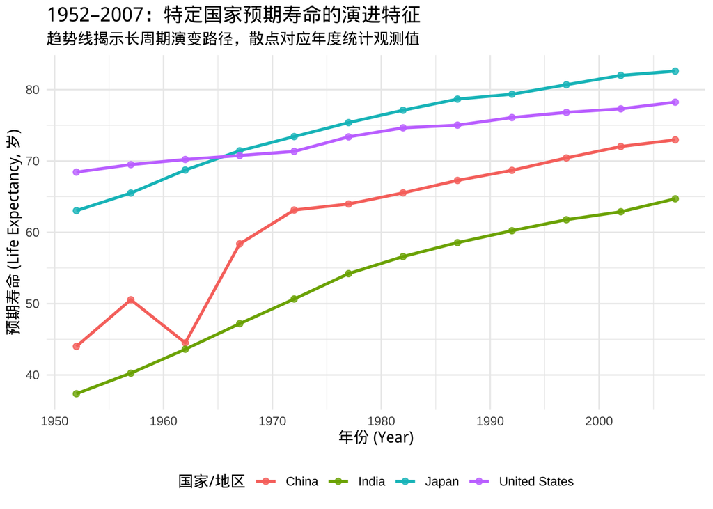

```r
library(tidyverse)
library(gapminder)

# 1. 数据预处理：构建跨时域多国对比样本
# 从 Gapminder 数据库中提取特定国家的时间序列观测值，用于呈现社会发展指标的动态演化
data_line <- gapminder %>%
  filter(country %in% c("China", "United States", "Japan", "India"))

# 2. 视觉映射与美学逻辑构建
ggplot(
  data = data_line,
  mapping = aes(
    x = year,
    y = lifeExp,
    color = country  # 将类别变量映射至色彩通道，实现多组样本的自动分组与区分
  )
) +
  # 3. 几何图层：趋势轨迹与观测落点的协同表述
  # geom_line 渲染演化趋势；geom_point 用于强调各年度的具体观测精度，提升数据信度
  geom_line(linewidth = 1) +
  geom_point(size = 1.8, alpha = 0.8) +

  # 4. 语义标注与视觉排版净化
  labs(
    title    = "1952–2007：特定国家预期寿命的演进特征",
    subtitle = "趋势线揭示长周期演变路径，散点对应年度统计观测值",
    x        = "年份 (Year)",
    y        = "预期寿命 (Life Expectancy, 岁)",
    color    = "国家/地区"
  ) +

  theme_minimal() + # 采用极简主义主题，通过提升“数据墨水比”聚焦核心统计信息
  theme(
    legend.position = "bottom", # 图例下置以优化绘图区域的纵向视觉纵深
    plot.title = element_text(face = "bold", size = 14)
  )
```

#### **图形解读：怎么读这张折线图？主要发现是什么？**

**怎么读**

- **① 起点—终点**：看每条线在 1952 与 2007 的高度差，用于比较总体提升幅度。
- **② 斜率**：线越陡，表示该阶段寿命提升越快；线越平，表示提升趋缓（边际改善减弱）。
- **③ 波动/拐点**：若出现下探、停滞或斜率突变，通常提示该阶段存在异常冲击或结构性变化，需回到数据与背景解释。

**据此读出的主要发现**

- **整体趋势**：四国在 1952–2007 年间总体持续上升（长期健康水平改善）。
- **增幅对比**：总体提升幅度存在明显差异：India 与 China 的提升更快（追赶型增长）；Japan 与 United States 的增幅相对有限（高位区间更易“趋缓”）。
- **水平分层**：Japan 全程处于高寿命水平；United States 也处于较高水平，但后期斜率更平（增长放缓）。
- **追赶与收敛**：China 与 India 起点较低（早期水平偏低）但上升更快，至 2000 年后与高寿命国家差距缩小（收敛趋势）。
- **结构性变化**：China 在 1950s 末至 1960s 初出现阶段性波动（短期回落/停滞），随后进入更稳定的上升通道；India 整体更平滑，呈持续累积式提升。

#### **警惕“伪趋势”：折线图的禁区**

重要

折线图的核心语义是连续变化：连线默认表示相邻点之间存在可解释的过渡关系（斜率具有实际含义）。当 x 轴不具备连续性或不代表同一对象的连续过程时，连线容易制造“伪趋势”，应避免使用。

**1. 无序类别变量**（Nominal Data）

- **不推荐**：x 轴为“中国、美国、日本”等类别。
- **原因**：类别之间没有连续过渡，连线会暗示不存在的变化方向与“中间状态”。
- **替代方案**：使用柱状图或点图（dot plot）进行离散比较。

**2. 离散区间 / 队列**（Discrete Cohorts）

- **不推荐**：x 轴为年龄段（如 `[10–19]`, `[20–29]`, `[30–39]`）。
- **原因**：年龄段通常对应不同群体的截面差异，而非同一对象的连续演变；连线容易被误读为个体成长轨迹。
- **替代方案**：对比均值/总量可用分组柱状图；强调分布差异可用箱线图/小提琴图（按组展示）。

**使用原则**：  
只有当你能合理说明相邻 x 值的斜率代表变化速率时，才使用折线图；否则优先采用离散比较图形（柱状图/点图/箱线图等）。

进阶 · 代码实战

基础折线图强调“**水平随时间变化**”。但在跨地区比较中，更关键的问题是：不同地区是否**同步改善**、改善速度是否**一致**、以及在某些时期是否出现**阶段性加速/放缓**。因此，本节将折线图升级为“**同图对照**”：在同一坐标框架下同时呈现 **各大洲的长期趋势**与**世界平均水平**，并加入洲内分布带以提示**洲内差异范围**。

**代码逻辑**：

Step 1 **构建“世界基准线”**（World reference/baseline）  
按 `year` 分组计算世界人口加权平均预期寿命 `world_lifeExp_w`，并将其重命名为 `lifeExp_w`。  
（人口加权使大人口国家对总体水平的贡献更合理，避免“小国均值”放大波动）

Step 2 **构建“洲—年趋势”与“洲内差异带”**（Continent trend + IQR band）  
按 `continent × year` 分组计算：  
- `lifeExp_w = Σ(lifeExp × pop) / Σ(pop)`（洲级人口加权均值）  
- `q25` 与 `q75`（洲内 25%/75% 分位数，用于 IQR 带）  
随后用 `geom_ribbon(ymin = q25, ymax = q75)` 绘制阴影带，作为“洲内差异范围”的背景提示，并通过 `show.legend = FALSE` 避免图例冗余。

Step 3 **合并绘图序列并区分 World / Continent**（用于线型与线宽）  
将 `cont_year` 与 `world_year` 合并为 `line_df`，并创建 `group_type`：  
- `Continent`：各大洲趋势（实线、较细）  
- `World`：世界参照线（虚线、较粗、darkred）  
从而在同一图层中用 `linetype/linewidth/size` 实现“视觉强调”但不增加额外图例项。

Step 4 **统一配色并加入图内说明**  
使用 `RColorBrewer::Set2` 为五大洲提供一致色值，并额外指定 `World = darkred`。同时让分布带 `fill` 与折线 `colour` 共享同一套映射，确保“带—线”一一对应。  
最后用 `annotate("label", x = Inf, y = -Inf, ...)` 在图内空白处标注：阴影带表示洲内 **25%–75%** 区间（IQR）。

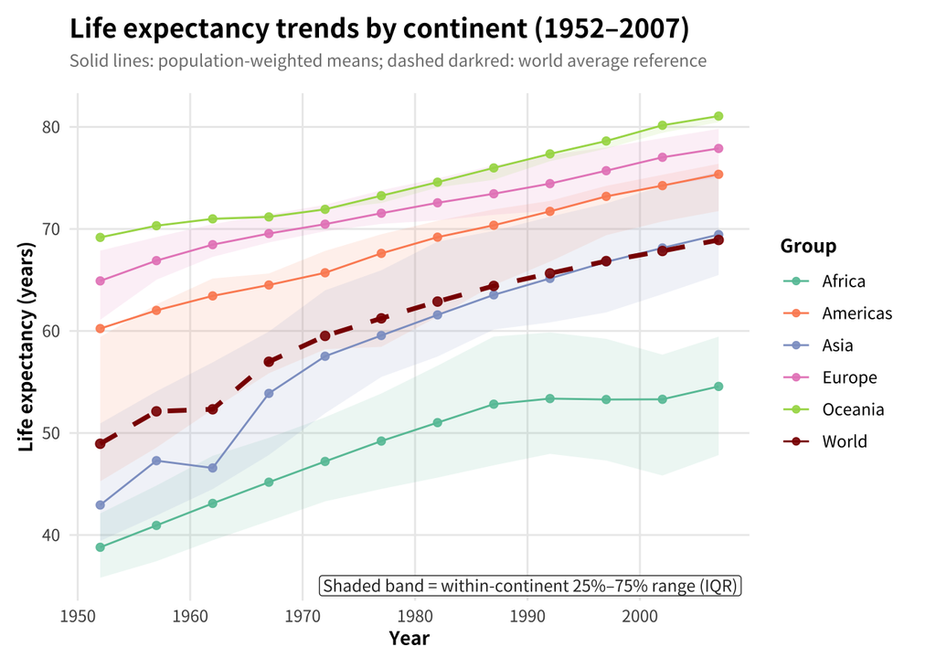

```r
# ==============================================================================
# 进阶时序分析：大洲趋势与全球基准对照 (加权均值与离散分布带)
# 核心技术：人口加权均值、分位数估计、复合图层叠加 (Ribbon + Line)
# ==============================================================================

library(tidyverse)
library(gapminder)
library(RColorBrewer)
library(showtext)

# ------------------------------------------------------------------------------
# 绘图环境配置：学术级字体渲染与数值显示优化
# ------------------------------------------------------------------------------
font_add_google(name = "Noto Sans SC", family = "my_font")
showtext_auto()
options(scipen = 9999) # 禁用科学计数法以增强轴标签的可读性

# ------------------------------------------------------------------------------
# 0) 统计量推导：洲级人口加权均值与四分位区间 (IQR) 估计
# ------------------------------------------------------------------------------
cont_year <- gapminder %>%
  group_by(continent, year) %>%
  summarise(
    # 计算人口加权均值：确保趋势反映的是“人的平均水平”而非“国家的平均水平”
    lifeExp_w = sum(lifeExp * pop, na.rm = TRUE) / sum(pop, na.rm = TRUE),
    # 提取洲内 25% 与 75% 分位数，用于呈现组内离散程度
    q25 = quantile(lifeExp, 0.25, na.rm = TRUE),
    q75 = quantile(lifeExp, 0.75, na.rm = TRUE),
    .groups = "drop"
  )

# ------------------------------------------------------------------------------
# 1) 参考基准计算：全球人口加权均值 (World Reference)
# ------------------------------------------------------------------------------
world_year <- gapminder %>%
  group_by(year) %>%
  summarise(
    lifeExp_w = sum(lifeExp * pop, na.rm = TRUE) / sum(pop, na.rm = TRUE),
    .groups = "drop"
  ) %>%
  mutate(continent = "World")

# ------------------------------------------------------------------------------
# 2) 结构化合并：构建包含参考组 (World) 的统一数据集
# ------------------------------------------------------------------------------
line_df <- bind_rows(
  cont_year %>% select(continent, year, lifeExp_w),
  world_year %>% select(continent, year, lifeExp_w)
) %>%
  mutate(
    # 定义分组属性：区分全球基准与大洲观察组，为后续美学映射奠定逻辑基础
    group_type = if_else(continent == "World", "World", "Continent"),
    continent  = factor(continent, levels = c(levels(gapminder$continent), "World"))
  )

# ------------------------------------------------------------------------------
# 3. 美学映射设计：高对比度学术色盘与元数据定义
# ------------------------------------------------------------------------------
set2_cols <- brewer.pal(5, "Set2")
cols_line  <- c(
  "Africa"   = set2_cols[1], "Americas" = set2_cols[2], "Asia" = set2_cols[3],
  "Europe"   = set2_cols[4], "Oceania"  = set2_cols[5], "World" = "darkred"
)

iqr_note <- "Shaded band = within-continent 25%–75% range (IQR)"

# ------------------------------------------------------------------------------
# 4. 可视化构建：分层图形呈现
# ------------------------------------------------------------------------------
ggplot() +

  # A. 离散度分布层：通过 geom_ribbon 呈现 IQR 阴影带，表征大洲内部的异质性
  geom_ribbon(
    data = cont_year,
    aes(x = year, ymin = q25, ymax = q75, fill = continent),
    alpha = 0.12, colour = NA, show.legend = FALSE
  ) +

  # B. 趋势轨迹层：利用 linetype 与 linewidth 构建视觉等级 (Hierarchy)
  # 全球基准 (World) 采用深红色虚线与加粗处理以实现视觉隔离
  geom_line(
    data = line_df,
    aes(x = year, y = lifeExp_w, colour = continent,
        linetype = group_type, linewidth = group_type)
  ) +

  # C. 观测落点层：强调年度统计节点
  geom_point(
    data = line_df,
    aes(x = year, y = lifeExp_w, colour = continent, size = group_type),
    alpha = 0.90
  ) +

  # D. 元数据注释层：利用 Inf 坐标实现标注内容的边界对齐
  annotate(
    "label",
    x = Inf, y = -Inf, label = iqr_note,
    hjust = 1.02, vjust = -0.25, size = 3.1,
    label.padding = unit(0.18, "lines"), linewidth = 0.25,
    colour = "grey20", fill = "white", alpha = 0.92, family = "my_font"
  ) +

  # ----------------------------------------------------------------------------
  # E. 标度控制与视觉排版净化
  # ----------------------------------------------------------------------------
  scale_colour_manual(values = cols_line, name = "Group") +
  scale_fill_manual(values = cols_line) +

  # 隐藏冗余的线型/大小图例，聚焦于色彩驱动的分组信息
  scale_linetype_manual(values = c("Continent" = "solid", "World" = "dashed"), guide = "none") +
  scale_linewidth_manual(values = c("Continent" = 0.5, "World" = 1.2), guide = "none") +
  scale_size_manual(values = c("Continent" = 1.7, "World" = 2.0), guide = "none") +

  labs(
    title    = "Life expectancy trends by continent (1952–2007)",
    subtitle = "Solid lines: population-weighted means; dashed darkred: world average reference",
    x        = "Year", y = "Life expectancy (years)"
  ) +

  theme_minimal() +
  theme(
    text          = element_text(family = "my_font"),
    plot.title    = element_text(face = "bold", size = 14, hjust = 0),
    plot.subtitle = element_text(size = 9, color = "grey50", face = "italic", margin = margin(b = 12)),
    axis.title    = element_text(face = "bold", size = 10),
    legend.title  = element_text(face = "bold", size = 10),
    panel.grid.minor = element_blank(),
    plot.margin   = margin(10, 18, 10, 10)
  )
```

#### **课外教程参考**

- **折线图**：[STHDA · ggplot2 line chart](https://www.sthda.com/english/wiki/ggplot2-line-plot-quick-start-guide-r-software-and-data-visualization#google_vignette)
- **时序图**：[STHDA · ggplot2 time series](https://www.sthda.com/english/articles/32-r-graphics-essentials/128-plot-time-series-data-using-ggplot/)

**© 华东师范大学 社会发展学院 人口研究所** | [**DAWN 研究组**](https://dawn-ecnu.github.io) | yzliu@soci.ecnu.edu.cn

课程负责人：刘贇喆 本章作者：刘贇喆 | 蒋娴静

最后更新：2026年03月19日 构建环境：R version 4.5.2 (2025-10-31)

[CC BY-NC-SA 4.0](https://creativecommons.org/licenses/by-nc-sa/4.0/deed.zh) 回到顶部

##### 柱状图

###### **3.3 柱状图：类别比较**

基础 · 图形概念

**柱状图**（Bar Chart） 是用于比较**分类变量**在某一**数值指标**上的差异的标准图形。它以柱子的**长度**作为主要编码通道，将数值大小映射为可直接比较的视觉差异，适用于跨类别对比、排序展示与结构呈现。

**1. 核心用途**

- **数值比较**：  
  对比不同类别的量级差异（如不同国家的人均 GDP）。
- **排名展示**：  
  按数值排序，快速识别“Top N / Last N”（最高/最低组别）。
- **部分与整体**：  
  使用堆叠柱状图展示总量的内部构成（composition）。

**2. 核心 ggplot geom**

> 核心 ggplot geom：`geom_col()` / `geom_bar()`

**3. 函数辨析**

在 `ggplot2` 中，柱状图常用两类几何对象，选择取决于数值是否已在数据表中：

- **`geom_col()`**：推荐  
  当数据表中**已经存在**要展示的数值列（如 GDP、人口、寿命）时使用：  
  柱高 = y 变量的实际数值
- **`geom_bar()`**：  
  当数据为**原始明细记录**，需要对类别进行**计数**（频数）时使用：  
  柱高 = 该类别出现次数

基础 · 代码实战

本节使用 `gapminder` 数据构建一个**最小可复现**的柱状图案例：聚焦 2007 年**美洲（Americas）**国家，筛选人均 GDP（`gdpPercap`）最高的 **Top 10**，并用**水平柱状图**呈现其排名差异。

- **数据处理目标**：限定 `year == 2007` 且 `continent == "Americas"`，并按 `gdpPercap` 取 Top 10（不含并列）。
- **图形表达目标**：用水平柱状图展示“从高到低”的排序结构，便于快速扫描比较。

**关键技巧**：类别变量若不重排，通常会按名称字典序显示。为得到“排名视图”，需要按 `gdpPercap` 对 `country` 进行重排（`reorder()` 或 `forcats::fct_reorder()`）。

**代码逻辑**：

Step 1 **筛选范围**（年份 × 大洲）  
限定 `year == 2007` 且 `continent == "Americas"`，得到目标比较集合。

Step 2 **提取 Top 10**（按人均 GDP 排名）  
使用 `slice_max(order_by = gdpPercap, n = 10, with_ties = FALSE)` 获取人均 GDP 最高的 10 个国家，保证排名集合唯一且可复现。

Step 3 **重排类别**（避免字典序）  
在映射中用 `reorder(country, gdpPercap)` 将国家按数值从低到高排列；配合水平柱状图即可呈现“从高到低”的视觉排序（y 轴自下而上）。

Step 4 **绘制柱状图并精简背景**  
用 `geom_col()` 直接绘制已汇总好的数值型柱形；再通过 `theme()` 去除 y 方向主网格线以提升读数清晰度。

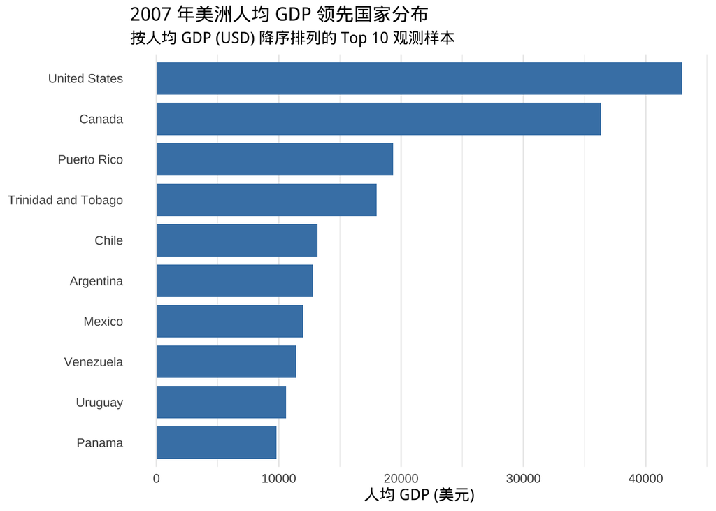

```r
library(tidyverse)
library(gapminder)

# 1. 数据预处理：提取 2007 年度美洲截面样本，并筛选人均 GDP 前 10 位国家
data_bar <- gapminder %>%
  filter(year == 2007, continent == "Americas") %>%
  # 基于统计指标执行降序筛选，确保样本的代表性与对比价值
  slice_max(order_by = gdpPercap, n = 10, with_ties = FALSE)

# 2. 绘图初始化与视觉映射逻辑构建
ggplot(
  data = data_bar,
  mapping = aes(
    # reorder(类别, 排序依据)：实施数值驱动的重排序逻辑，优化名义变量的展示可读性
    x = gdpPercap,
    y = reorder(country, gdpPercap)
  )
) +
  # 3. 几何层：构建统计柱状图
  # 调用 geom_col() 以直接映射观测值（Identity mapping），而非执行频数统计
  geom_col(
    fill = "#4682B4",
    width = 0.8
  ) +
  # 4. 标注体系与美学净化
  labs(
    title    = "2007 年美洲人均 GDP 领先国家分布",
    subtitle = "按人均 GDP (USD) 降序排列的 Top 10 观测样本",
    x        = "人均 GDP (美元)",
    y        = NULL
  ) +
  theme_minimal() +
  # 细节优化：移除冗余的纵向分类网格线，通过提升“数据墨水比”引导读数视觉重心
  theme(
    panel.grid.major.y = element_blank()
  )
```

#### **图形解读：怎么读这张柱状图？**

**读图方法**

- **看坐标含义**：  
  横轴是人均 GDP（美元），纵轴是国家/地区；每一条**柱子**对应一个国家，柱子的长度表示该国的人均 GDP 水平。
- **看排序规则**：  
  本图已按人均 GDP 降序排列，因此从上到下就是“Top 10”排名；阅读时可直接按顺序识别名次。
- **看差距（gap）**：  
  重点比较相邻柱子的长度差异：差距越大，说明经济水平分层越明显；差距较小，则表示该段国家之间更接近。

**从图中可直接读出的主要信息**

- **头部集中**：  
  美国与加拿大的柱长明显领先，处于该区域的人均 GDP 高位水平。
- **断层与层级**：  
  第二名之后出现明显“断层”（从加拿大到第三名柱长显著变短），提示高收入国家与其余国家存在清晰分层。
- **中后段更接近**：  
  第三名之后（如 Puerto Rico、Trinidad and Tobago、Chile 等）柱长差异相对缩小，说明这一梯队内部差距较有限。

###### **堆叠柱状图：总量与结构**

进阶 · 图形概念

**1. 图形定义**

标准柱状图强调“类别—数值”的单一对比。**堆叠柱状图**（Stacked Bar Chart）在同一根柱子内叠加多个子类别，使图形在一个坐标系中同时表达**总量**与**结构**两类信息：

- **柱子总高度**：表示该主类别的**总量**（Total Magnitude）。
- **内部色块**：表示总量的**构成成分**（Composition），色块高度对应各子类别的贡献大小。

> 使用要点：堆叠柱状图适合“看总量 + 看组成”；但若目标是精确比较不同主类别间的子类别大小，需要谨慎解读（堆叠基线不同会影响比较）。

**2. 场景与目标**

本案例希望在一张图中同时回答两类问题：  
- 各大洲的经济体量谁更大（总量比较）？  
- 每个大洲的经济体量主要由哪些国家贡献（结构识别）？

**3. 数据策略**

以 2007 年为截面，先计算国家 GDP 总量  
`GDP = pop × gdpPercap`（人口 × 人均 GDP）。

若将每个大洲所有国家都堆叠到一根柱内，色块与图例会急剧膨胀、可读性下降。因此采用“**Top2 + Others**”的结构化汇总：  
- 每洲仅保留 GDP 贡献最高的 **Top1 / Top2** 作为独立色块；  
- 其余国家合并为该洲的 **Others**（Other__）；  
- 并用“同洲同色系”的明暗变化表达 Top1/Top2/Others，使读者能快速识别洲内结构而不跳色。

进阶 · 代码实战

本节代码围绕“**洲总量 + 洲内结构（Top2 + Others）**”构建堆叠柱状图，并在图例中附带各色块的**洲内占比**，以提升读图效率。

**代码逻辑**：

Step 1 **参数与配色锚点**（continent_order + base_cols）  
设定分析年份 `year_sel = 2007` 与大洲显示顺序 `continent_order`；随后用 `ggsci::pal_d3("category10")` 为每个大洲分配一个**基色** `base_cols`（作为同洲配色的“锚点”）。  
同时定义颜色插值函数 `mix_col()` 与 `shade_triplet()`，将每个大洲的基色扩展为三档明暗：Top1 / Top2 / Others（同色系一致、结构层级清晰）。

Step 2 **国家层数据构造：计算 country_gdp**  
筛选 `year == 2007`，并计算  
`country_gdp = pop * gdpPercap`（国家 GDP 总量代理）；同时将 `continent` 设为按 `continent_order` 排列的因子，以固定柱子顺序并保证跨图一致性。

Step 3 **洲内 Top2 识别：生成 top2_map**（含 rank）  
按 `continent` 分组，在组内按 `country_gdp` 降序排列并截取前 2 个国家，形成 `top2_map`：  
- `rank_in_continent = 1` → Top1  
- `rank_in_continent = 2` → Top2  
随后拆分得到 `top1` 与 `top2` 两个清单，用于后续堆叠顺序与颜色映射。

Step 4 **结构化汇总**：Top1 / Top2 / Other__洲 + 洲内占比 pct  
将 `top2_map` 回连到国家数据：  
- Top1/Top2 保留国家名作为 `segment`；  
- 其余国家合并为 `segment = "Other__<Continent>"`（保证每个大洲的 Others 是独立段）。  
再按 `continent × segment` 汇总得到 `gdp_sum`，并在洲内计算  
`pct = gdp_sum / sum(gdp_sum)`（用于图例显示“洲内占比”）。

Step 5 **堆叠顺序控制：Others → Top2 → Top1**（从下到上）  
构造 `stack_levels`：先放所有 `Other__<Continent>`，再放各洲 Top2 国家，最后放 Top1 国家；并将 `segment` 设置为该顺序的因子。  
同时在 `geom_col()` 中使用 `position_stack(reverse = TRUE)`，使堆叠方向与因子顺序共同作用，稳定实现“底部 Others、顶部 Top1”的版式。

Step 6 **颜色映射：同洲同色系**（三档明暗）  
遍历 `continent_order`，对每个大洲基色生成 `shades = shade_triplet(base)`，并将：  
- `Top1` 映射到 `shades["top1"]`  
- `Top2` 映射到 `shades["top2"]`  
- `Other__<Continent>` 映射到 `shades["other"]`  
最终形成 `fill_values`，确保每个 `segment` 都有明确填色（不依赖默认调色）。

Step 7 **图例组织：按洲分组排序 + 标签附带占比**  
构造 `legend_df`，按每个大洲依次生成图例顺序：Top1 → Top2 → Others，并把 `pct` 拼接到标签文本中：  
- 国家段：`Country (xx%)`  
- Others 段：`Continent: Others (xx%)`  
随后用 `scale_fill_manual(breaks = ..., labels = ...)` 显式控制图例顺序与标签内容。

Step 8 **绘图输出：堆叠柱 + 单位换算 + 字体统一**  
使用 `geom_col()` 绘制堆叠柱；`scale_y_continuous(labels = label_number(scale = 1e-12, suffix = "T"))` 将数量级转换为 Trillion；最后在 `theme()` 中统一使用 `my_font`，并规范标题、轴文字与图例排版以匹配全文视觉风格。

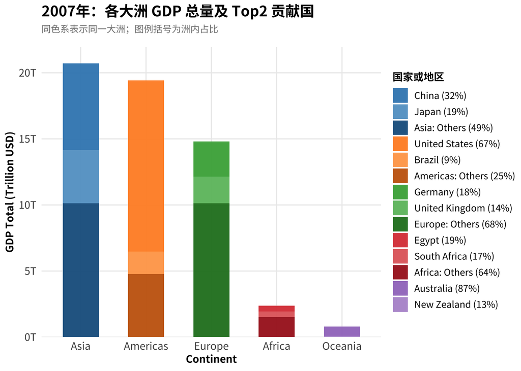

```r
# ============================================================
# 0) Packages + 字体（统一：Noto Sans SC -> my_font）
# ============================================================
library(tidyverse)
library(gapminder)
library(ggsci)
library(scales)
library(showtext)
library(sysfonts)

# -----------------------------
# 字体：Noto Sans SC
# -----------------------------
font_add_google(name = "Noto Sans SC", family = "my_font")
showtext_auto()
options(scipen = 9999)

# ============================================================
# 1) 参数
# ============================================================
year_sel <- 2007

# 研究设定：固定大洲展示顺序（便于跨图比较）
continent_order <- c("Asia", "Americas", "Europe", "Africa", "Oceania")

# 主色：为每个大洲分配一个分类调色板的“基色”（同洲同色系锚点）
base_cols <- ggsci::pal_d3("category10")(length(continent_order))
names(base_cols) <- continent_order

bar_width <- 0.55
pct_acc   <- 1  # 图例中占比精度（整数百分比）

# ------------------------------------------------------------
# 颜色工具：基色 -> 同色系明暗（Top1/Top2/Others）
# ------------------------------------------------------------
mix_col <- function(a, b, w = 0.5) {
  rgb(colorRamp(c(a, b))(w) / 255)
}

shade_triplet <- function(base) {
  c(
    top1  = mix_col(base, "white", 0.12),  # Top1：略亮（视觉主导但不跳色）
    top2  = mix_col(base, "white", 0.30),  # Top2：更亮（强化区分）
    other = mix_col(base, "black", 0.22)   # Others：略暗（压低但同色系）
  )
}

# ============================================================
# 2) 数据：国家 GDP 总量（pop × gdpPercap）
# ============================================================
df_country <- gapminder %>%
  filter(year == year_sel) %>%
  mutate(
    continent   = factor(continent, levels = continent_order), # 固定绘图顺序
    country     = as.character(country),
    country_gdp = pop * gdpPercap
  )

# ============================================================
# 3) 每洲 Top2（按国家 GDP 总量贡献排序）
# ============================================================
top2_map <- df_country %>%
  group_by(continent) %>%
  arrange(desc(country_gdp), .by_group = TRUE) %>%
  slice_head(n = 2) %>%
  mutate(rank_in_continent = row_number()) %>%
  ungroup() %>%
  select(continent, country, rank_in_continent)

top1 <- top2_map %>% filter(rank_in_continent == 1)
top2 <- top2_map %>% filter(rank_in_continent == 2)

# ============================================================
# 4) 汇总：Top1 / Top2 / Other__洲，并计算洲内占比 pct
# ============================================================
plot_stack <- df_country %>%
  left_join(top2_map, by = c("continent", "country")) %>%
  mutate(
    # Top2 国家保留国家名；其余合并为 “Other__<Continent>”
    segment = if_else(
      !is.na(rank_in_continent),
      country,
      paste0("Other__", as.character(continent))
    )
  ) %>%
  group_by(continent, segment) %>%
  summarise(gdp_sum = sum(country_gdp), .groups = "drop") %>%
  group_by(continent) %>%
  mutate(pct = gdp_sum / sum(gdp_sum)) %>%
  ungroup()

# ============================================================
# 5) 堆叠顺序：底部 Others -> 中间 Top2 -> 顶部 Top1
# ============================================================
stack_levels <- c(
  paste0("Other__", continent_order),
  top2$country,
  top1$country
) %>% unique()

plot_stack <- plot_stack %>%
  filter(segment %in% stack_levels) %>%
  mutate(segment = factor(segment, levels = stack_levels))

# ============================================================
# 6) 颜色映射：每洲基色 -> 三档明暗（Top1/Top2/Others）
# ============================================================
fill_values <- c()

for (ct in continent_order) {
  shades <- shade_triplet(base_cols[[ct]])

  top1_ct <- top1 %>% filter(as.character(continent) == ct) %>% pull(country)
  top2_ct <- top2 %>% filter(as.character(continent) == ct) %>% pull(country)
  oth_ct  <- paste0("Other__", ct)

  fill_values[top1_ct] <- shades["top1"]
  fill_values[top2_ct] <- shades["top2"]
  fill_values[oth_ct]  <- shades["other"]
}

# ============================================================
# 7) 图例：按洲顺序 Top1 -> Top2 -> "<Continent>: Others"
# ============================================================
legend_df <- map_dfr(continent_order, function(ct) {
  top1_ct <- top1 %>% filter(as.character(continent) == ct) %>% pull(country)
  top2_ct <- top2 %>% filter(as.character(continent) == ct) %>% pull(country)
  oth_ct  <- paste0("Other__", ct)

  segs <- c(top1_ct, top2_ct, oth_ct)
  segs <- segs[segs %in% as.character(plot_stack$segment)]

  tibble(segment_chr = segs) %>%
    left_join(
      plot_stack %>% transmute(segment_chr = as.character(segment), pct),
      by = "segment_chr"
    ) %>%
    mutate(
      label = case_when(
        str_detect(segment_chr, "^Other__") ~ paste0(ct, ": Others (", percent(pct, accuracy = pct_acc), ")"),
        TRUE ~ paste0(segment_chr, " (", percent(pct, accuracy = pct_acc), ")")
      )
    )
})

legend_breaks <- legend_df$segment_chr
legend_labels <- legend_df$label

# ============================================================
# 8) 绘图：堆叠柱（洲总量）+ 洲内 Top2 + Others
# ============================================================
ggplot(plot_stack, aes(x = continent, y = gdp_sum, fill = segment)) +
  geom_col(
    width = bar_width,
    alpha = 0.95,
    position = position_stack(reverse = TRUE)
  ) +
  scale_fill_manual(
    values = fill_values,
    breaks = legend_breaks,
    labels = legend_labels,
    drop   = FALSE,
    guide  = guide_legend(
      byrow = TRUE,
      keyheight = unit(0.55, "cm"),
      keywidth  = unit(0.55, "cm")
    )
  ) +
  scale_y_continuous(
    labels = label_number(scale = 1e-12, suffix = "T"),
    expand = expansion(mult = c(0, 0.06))
  ) +
  labs(
    title    = "2007年：各大洲 GDP 总量及 Top2 贡献国",
    subtitle = "同色系表示同一大洲；图例括号为洲内占比",
    x = "Continent",
    y = "GDP Total (Trillion USD)",
    fill = "国家或地区"
  ) +
  theme_minimal() +
  theme(
    # --- 字体统一 ---
    plot.title    = element_text(family = "my_font", face = "bold", size = 14, hjust = 0),
    plot.subtitle = element_text(family = "my_font", size = 9, color = "grey50",
                                 face = "italic", margin = margin(b = 12)),
    axis.title    = element_text(family = "my_font", face = "bold", size = 10),
    axis.text     = element_text(family = "my_font", size = 10),

    legend.position  = "right",
    legend.text      = element_text(family = "my_font", size = 9),
    legend.title     = element_text(family = "my_font", size = 10, face = "bold"),
    legend.spacing.y = unit(0.2, "cm"),
    legend.margin    = margin(t = 0, b = 0, l = 0, r = 0),

    panel.grid.minor = element_blank()
  )
```

#### **课外教程参考**

- **堆叠柱状图**：[Grouped & Stacked barplot](https://r-graph-gallery.com/48-grouped-barplot-with-ggplot2.html)
- **柱状图**：[STHDA · ggplot2 bar chart](https://www.sthda.com/english/wiki/ggplot2-barplots-quick-start-guide-r-software-and-data-visualization)

**© 华东师范大学 社会发展学院 人口研究所** | [**DAWN 研究组**](https://dawn-ecnu.github.io) | yzliu@soci.ecnu.edu.cn

课程负责人：刘贇喆 本章作者：刘贇喆 | 蒋娴静

最后更新：2026年03月19日 构建环境：R version 4.5.2 (2025-10-31)

[CC BY-NC-SA 4.0](https://creativecommons.org/licenses/by-nc-sa/4.0/deed.zh) 回到顶部

##### 直方图

###### **3.4 直方图：频数分布**

基础 · 图形概念

**直方图**（Histogram） 用于刻画**单个连续变量**的分布形态。它将连续取值按给定组距划分为若干区间（Bins），并统计每个区间内的观测频数，从而以“柱形轮廓”近似呈现数据的整体结构与集中趋势。

**1. 核心用途**

- **分布诊断**：  
  识别近似正态、左偏/右偏（Skewness）、长尾（Heavy tail）或多峰（Multimodal）等形态特征。
- **集中区间识别**：  
  定位样本主要聚集的取值范围（主体区间），辅助选择描述性统计与阈值划分。
- **极端值线索**：  
  观察分布两端是否出现稀疏“孤立柱”（潜在离群/极端观测）。

**2. 易混淆辨析：直方图 vs 柱状图**

- **直方图**（`geom_histogram()`）：  
  横轴为**连续数值**（如年龄、工资、lifeExp）；柱体通常**相邻无间隙**，强调**区间划分**与**连续性**。
- **柱状图**（`geom_col()` / `geom_bar()`）：  
  横轴为**离散类别**（如国家、性别、行业）；柱体通常**有间隙**，强调**类别之间**相互独立。

**3. 核心函数**

在 `ggplot2` 中，直方图对应的几何对象函数为：

> **`geom_histogram()`**

基础 · 代码实战

以 **2007 年**各国的 **预期寿命** `lifeExp`（gapminder） 为例，使用直方图对连续变量进行分箱统计，用于快速识别预期寿命的**集中区间**、整体**偏态特征**以及是否存在**长尾/极端值**。

**代码逻辑**：

Step 1 **筛选截面数据**（固定分析年份）  
从 `gapminder` 中选取 `year == 2007` 的观测，得到单一年份的截面数据 `data_hist`，用于展示该年的 `lifeExp` 分布形态。

Step 2 **建立映射关系**（连续变量 → x 轴）  
在 `ggplot()` 中将连续变量 `lifeExp` 映射到 `x`（`aes(x = lifeExp)`），为后续的分箱统计与柱形绘制提供基础坐标系。

Step 3 **分箱统计并绘制直方图**（控制分辨率）  
使用 `geom_histogram()` 自动完成分箱计数并绘制柱形；通过 `binwidth = 2` 指定组距为 2 年：  
组距越小细节越多、越大则更平滑（直方图“分辨率”控制）。

Step 4 **补充图形信息**（标题/坐标轴/主题）  
用 `labs()` 明确标题与坐标轴含义，其中 `y = "Count"` 表示柱高为每个分箱内的观测数量；最后用 `theme_minimal()` 统一简洁风格。

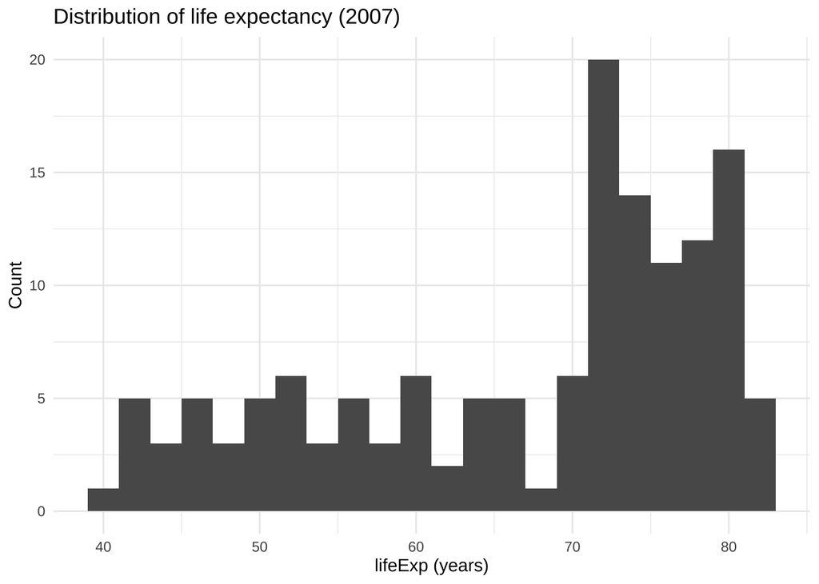

```r
# 0) 数据：筛选 2007 年（直方图示例年）
library(tidyverse)
library(gapminder)

data_hist <- gapminder %>%
  filter(year == 2007)

# 1) 直方图：lifeExp 分箱统计（组距=2 年）
ggplot(data_hist, aes(x = lifeExp)) +
  geom_histogram(binwidth = 2) +
  labs(
    title = "Distribution of life expectancy (2007)",
    x = "lifeExp (years)",
    y = "Count"
  ) +
  theme_minimal()
```

进阶 · 代码实战

本节以 **2007 年**为截面考察全球各国的**预期寿命分布**，在同一坐标系中同时呈现：直方图的**分箱结构**、核密度曲线的连续轮廓、样本落点（rug），以及**均值**与**中位数**两条参考线，用于辅助识别分布的集中区间与整体偏移。

**代码逻辑**：

Step 1 **数据筛选：锁定单一年份截面**  
从 `gapminder` 中筛选 `year == 2007` 得到 `data_hist`，确保后续所有统计量（直方图、KDE、均值/中位数）均基于同一截面数据计算，避免时间混杂。

Step 2 **密度曲线预计算：KDE → 坐标表 dens_df**  
使用 `density(data_hist$lifeExp)` 计算核密度估计（KDE），并将输出的 `x` 与 `y` 组织为 `dens_df`（tibble）。  
该步骤的目的是把“连续分布轮廓”显式转为可绘制的数据框，便于后续用 `geom_area()` 与 `geom_line()` 叠加到同一图层体系中。

Step 3 **参考统计量：均值/中位数 → ref_df**  
在 `data_hist` 上计算 `mean_lifeExp` 与 `median_lifeExp`（存入 `ref_df`），作为两条竖直参考线的定位依据。  
这两条统计量分别刻画“均衡中心”（均值）与“稳健中心”（中位数），用于读图时对分布中心位置进行快速对照。

Step 4 **统一标度：直方图切换为 density，并提取 y_top**  
为使直方图与 KDE 在同一 y 轴上可叠加，将直方图统计量切换为密度刻度：  
`aes(y = after_stat(density))`（柱高表示密度而非频数）。  
随后构建临时图 `p_tmp` 并用 `ggplot_build()` 提取直方图的最大密度 `y_top`，用于：  
- 限制均值/中位数参考线的高度（避免超过绘图区）；  
- 提供标签放置的相对高度基准（如 `0.98*y_top`）。

Step 5 **标签数据框：label_df 管理文本与坐标**  
将两条标签（Mean / Median）及其放置坐标写入 `label_df`，用 `geom_label()` 一次性绘制。  
该做法便于统一调整标签位置与字号，且避免在不同 ggplot2 版本中反复依赖 `annotate()` 的细节参数。

Step 6 **分层绘制：Histogram → Rug → KDE（面积+线）→ 参考线 → 标签**  
按信息层级依次叠加图层：  
- `geom_histogram(..., y = after_stat(density))`：给出分箱结构（底图）。  
- `geom_rug()`：补充样本在 x 轴上的落点密集区（细节线索）。  
- `geom_area()` + `geom_line()`：以统一基色 `kde_col` 绘制 KDE 面积与轮廓线（连续形态）。  
- `geom_segment()`：绘制均值（虚线）与中位数（实线）两条参考线，线段高度按 `y_top` 控制。  
- `geom_label()`：添加数值标签，并指定 `family = "my_font"` 以统一字体输出。

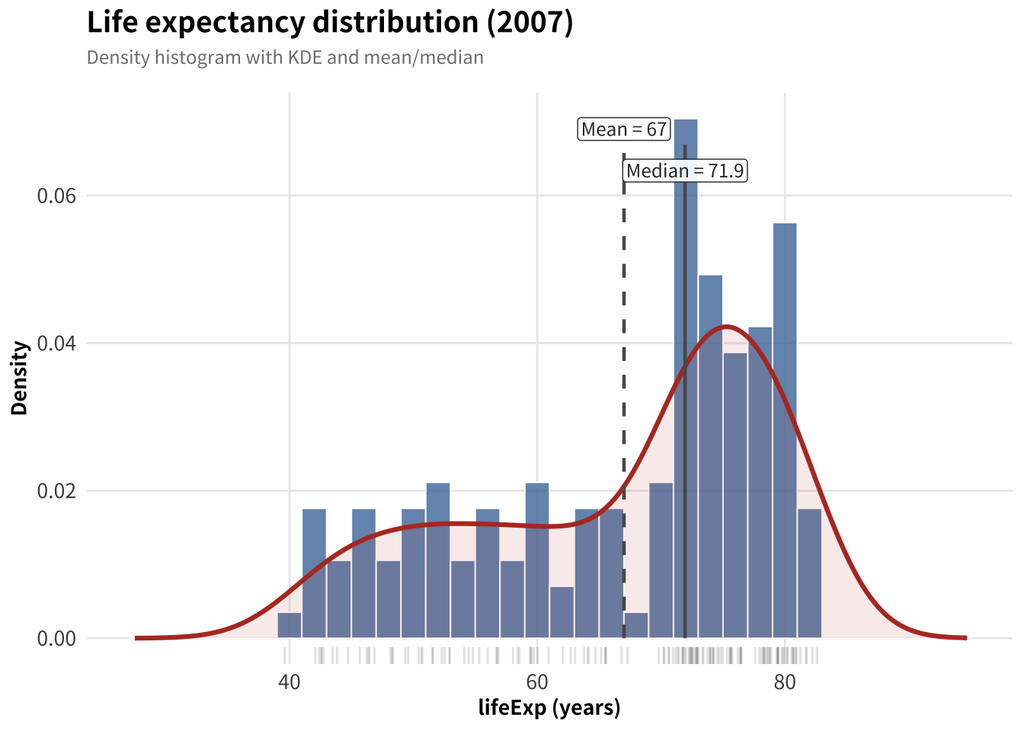

[interactive chart not shown]

```r
# ============================================================
# 进阶：Histogram + KDE + Rug + Mean/Median（density 标度）
# ============================================================

library(tidyverse)
library(gapminder)
library(showtext)

# -----------------------------
# 字体：Noto Sans SC
# -----------------------------
font_add_google(name = "Noto Sans SC", family = "my_font")
showtext_auto()
options(scipen = 9999)

# -----------------------------
# 0) 数据：2007 年截面（单变量分布示例）
# -----------------------------
data_hist <- gapminder %>%
  filter(year == 2007)

# -----------------------------
# 1) KDE：预计算密度曲线坐标（用于面积 + 曲线叠加）
# -----------------------------
dens_df <- density(data_hist$lifeExp, na.rm = TRUE) %>%
  with(tibble(x = x, y = y))

# -----------------------------
# 2) 参考统计量：均值 / 中位数（参考线与数值标签）
# -----------------------------
ref_df <- data_hist %>%
  summarise(
    mean_lifeExp   = mean(lifeExp, na.rm = TRUE),
    median_lifeExp = median(lifeExp, na.rm = TRUE)
  )

# -----------------------------
# 3) y 轴上限：从 density 直方图提取最大 density（控制线段高度与标签位置）
# -----------------------------
p_tmp <- ggplot(data_hist, aes(x = lifeExp)) +
  geom_histogram(aes(y = after_stat(density)), binwidth = 2)

y_top <- max(ggplot_build(p_tmp)$data[[1]]$density, na.rm = TRUE)

# -----------------------------
# 4) 统一色系：KDE 曲线与面积共用同一基色
# -----------------------------
kde_col <- "#B53A2A"

# -----------------------------
# 5) 标签数据：用数据框管理文本与坐标（便于调整）
# -----------------------------
label_df <- tibble(
  x = c(ref_df$mean_lifeExp, ref_df$median_lifeExp),
  y = c(0.98 * y_top, 0.90 * y_top),
  lab = c(
    paste0("Mean = ", round(ref_df$mean_lifeExp, 1)),
    paste0("Median = ", round(ref_df$median_lifeExp, 1))
  )
)

# -----------------------------
# 6) 出图：density 直方图 + KDE（面积+线）+ rug + 均值/中位数（线+数值）
# -----------------------------
ggplot(data_hist, aes(x = lifeExp)) +

  # 直方图：切换到 density 标度（与 KDE 同轴叠加）
  geom_histogram(
    aes(y = after_stat(density)),
    binwidth = 2,                  # 分箱组距：2 年（可按信息密度调整）
    fill = "#4C78A8",
    colour = "white",
    linewidth = 0.35,
    alpha = 0.80
  ) +

  # rug：样本落点（补充 x 轴上的细部聚集）
  geom_rug(alpha = 0.12, sides = "b") +

  # KDE 面积：透明填充（避免遮挡柱形）
  geom_area(
    data = dens_df,
    aes(x = x, y = y),
    fill = kde_col,
    alpha = 0.10,
    inherit.aes = FALSE
  ) +

  # KDE 曲线：分布轮廓线
  geom_line(
    data = dens_df,
    aes(x = x, y = y),
    colour = kde_col,
    linewidth = 1.1,
    inherit.aes = FALSE
  ) +

  # 均值线：虚线（线段高度限制在图内）
  geom_segment(
    data = ref_df,
    aes(x = mean_lifeExp, xend = mean_lifeExp, y = 0, yend = 0.95 * y_top),
    linetype = "dashed",
    linewidth = 0.8,
    colour = "grey35",
    inherit.aes = FALSE
  ) +

  # 中位数线：实线（线段高度限制在图内）
  geom_segment(
    data = ref_df,
    aes(x = median_lifeExp, xend = median_lifeExp, y = 0, yend = 0.95 * y_top),
    linetype = "solid",
    linewidth = 0.8,
    colour = "grey35",
    inherit.aes = FALSE
  ) +

  # 数值标签：与参考线对应（必要时只需改 y 或 size）
  geom_label(
    data = label_df,
    aes(x = x, y = y, label = lab),
    inherit.aes = FALSE,
    size = 3.2,
    linewidth = 0.25,
    label.padding = unit(0.15, "lines"),
    colour = "grey20",
    fill = "white",
    alpha = 0.90,
    family = "my_font"
  ) +

  # 标题与坐标
  labs(
    title = "Life expectancy distribution (2007)",
    subtitle = "Density histogram with KDE and mean/median",
    x = "lifeExp (years)",
    y = "Density"
  ) +

  # 主题：字体样式
  theme_minimal() +
  theme(
    plot.title    = element_text(family = "my_font", face = "bold", size = 14, hjust = 0),
    plot.subtitle = element_text(family = "my_font", size = 9, color = "grey50",
                                 face = "italic", margin = margin(b = 12)),
    axis.title    = element_text(family = "my_font", face = "bold", size = 10),
    axis.text     = element_text(family = "my_font", size = 10),
    panel.grid.minor = element_blank()
  )
```

#### **课外教程参考**

- **直方图**：[STHDA · ggplot2 histogram](https://www.sthda.com/english/wiki/ggplot2-histogram-plot-quick-start-guide-r-software-and-data-visualization)
- **QQ 图（正态性检验）**：[Datanovia · ggplot2 QQ plot](https://www.datanovia.com/en/lessons/ggplot-qq-plot/)

**© 华东师范大学 社会发展学院 人口研究所** | [**DAWN 研究组**](https://dawn-ecnu.github.io) | yzliu@soci.ecnu.edu.cn

课程负责人：刘贇喆 本章作者：刘贇喆 | 蒋娴静

最后更新：2026年03月19日 构建环境：R version 4.5.2 (2025-10-31)

[CC BY-NC-SA 4.0](https://creativecommons.org/licenses/by-nc-sa/4.0/deed.zh) 回到顶部

##### 雷达图

###### **3.5 雷达图：多维对比与结构画像**

基础 · 图形概念

**雷达图**（Radar Chart） 用于呈现**多个变量**在同一对象上的取值结构，并支持在同一坐标框架下对比多个对象的多维表现。它将各变量映射到从中心辐射的**角向轴**，并以闭合的线或多边形连接各维度取值，从而形成可直观识别的“结构画像”。

**1. 核心用途**

- **多维对比**：  
  比较不同对象在多个指标维度上的相对水平差异。  
  （例如：不同国家在预期寿命、收入、人口等指标上的综合表现）
- **结构画像**：  
  识别对象的优势维度与短板维度，并观察维度间的均衡性。  
  （Profile / Pattern）
- **综合评估呈现**：  
  将多指标评分结果以同一图形呈现，便于跨对象的整体对照。  
  （Performance / Index-based assessment）

**2. 核心函数**

在本章中，我们采用 `fmsb` 包绘制雷达图。其实现基于**多边形连线**与**同心网格刻度**，并提供对边框、填充与网格的直接控制。

> **`fmsb::radarchart()`**

#### **关于 `fmsb`：安装与使用**

本章雷达图的核心函数为：

> **`fmsb::radarchart()`**  
> （需先安装并加载 `fmsb` 包）

`fmsb` 可通过 CRAN 直接安装：

```r
install.packages("fmsb")
library(fmsb)
```

- `radarchart()`：用于绘制雷达图主体（轴线 / 网格 / 多边形）。
- `pfcol` / `pcol`：分别控制多边形**填充色**与**边框色**（可设置透明度）。

基础 · 代码实战

使用 `mtcars` 数据绘制基础雷达图，用于展示单一车型（Mazda RX4）在多个性能指标上的**相对结构画像**。

**代码逻辑**：

Step 1 **设定对象与指标体系**（统一比较维度）  
先选定目标车型 `car_name`，并明确多维指标集合 `vars`（mpg, hp, qsec, wt, drat）；同时准备 `vars_zh` 作为中文轴标签，仅用于展示，不参与计算。

Step 2 **按指标做 min–max 标准化**（把量纲压到同一尺度）  
将 `mtcars` 转为长表后，以每个指标 `var` 为分组，在全样本范围内计算 min–max，并得到 `score ∈ [0,1]`（相对位置）；随后筛选目标车型并回到宽表结构，为雷达图一行多变量输入做准备。

Step 3 **构造 fmsb 的专用输入**（先 max/min，再放目标对象）  
`fmsb::radarchart()` 要求数据前两行分别为**上界**与**下界**（用于固定坐标轴尺度与网格刻度），因此先构造 `row_max`（全 1）与 `row_min`（全 0），再与目标车型数据 `df_radar` 依次拼接为 `radar_in`。

Step 4 **中文化轴标签并绘图**  
将 `radar_in` 的列名替换为 `vars_zh` 以显示中文维度；随后调用 `radarchart()`：用 `pcol/pfcol` 设置轮廓与同色系透明填充，用 `plwd` 强化主体边界，并用 `axistype` 控制坐标轴刻度呈现；最后用 `title()` 补充主标题。

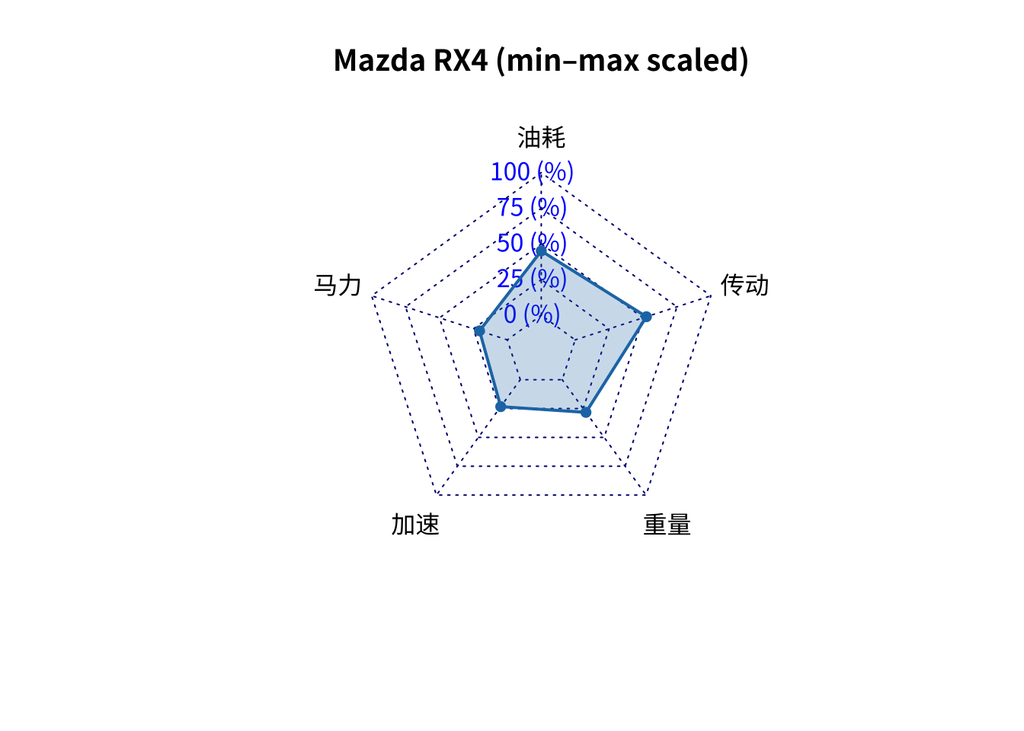

```r
# ==============================================================================
# mtcars 单车雷达图（Mazda RX4）— fmsb 版本
# 目标：把多指标表现压到同一尺度（[0,1]），再用雷达图呈现“结构画像”
# ==============================================================================
library(tidyverse)
library(fmsb)
library(showtext)
library(sysfonts)
library(scales)

# -----------------------------
# 字体：Noto Sans SC（统一 family = "my_font"）
# -----------------------------
font_add_google(name = "Noto Sans SC", family = "my_font")
showtext_auto()
options(scipen = 9999)

# ==============================================================================
# 1) 分析设定：对象 + 维度（英文变量名用于计算）
# ==============================================================================
car_name <- "Mazda RX4"
vars     <- c("mpg", "hp", "qsec", "wt", "drat")

# 维度中文名：仅用于轴标签显示（不参与计算）
vars_zh  <- c("油耗", "马力", "加速", "重量", "传动")

# ==============================================================================
# 2) 数据准备：按“指标维度”做 min–max 标准化 → [0,1]
#    说明：以 mtcars 全样本作为参照，得到该车在每个指标上的相对位置
# ==============================================================================
df_radar <- mtcars %>%
  rownames_to_column("car") %>%
  select(car, all_of(vars)) %>%
  pivot_longer(-car, names_to = "var", values_to = "raw") %>%
  group_by(var) %>%
  mutate(
    score = (raw - min(raw, na.rm = TRUE)) / (max(raw, na.rm = TRUE) - min(raw, na.rm = TRUE))
  ) %>%
  ungroup() %>%
  filter(car == car_name) %>%
  select(var, score) %>%
  pivot_wider(names_from = var, values_from = score)

# ==============================================================================
# 3) fmsb 输入格式：需在数据前加入 max/min 两行（用于固定坐标尺度）
# ==============================================================================
row_max <- as_tibble(setNames(as.list(rep(1, length(vars))), vars))  # 上界：1
row_min <- as_tibble(setNames(as.list(rep(0, length(vars))), vars))  # 下界：0

radar_in <- bind_rows(row_max, row_min, df_radar) %>%
  as.data.frame()

# 轴标签中文化：仅替换列名（不影响数值）
colnames(radar_in) <- vars_zh

# ==============================================================================
# 4) 出图：边框线 + 同色系透明填充
# ==============================================================================
op <- par(family = "my_font")  # base 图形系统：指定 showtext 注册的字体 family

fmsb::radarchart(
  radar_in,

  # -----------------------------
  # 多边形样式（主体）
  # -----------------------------
  pcol  = "#1f78b4",                      # 轮廓线颜色（polygon border）
  pfcol = scales::alpha("#1f78b4", 0.25), # 填充色 + 透明度（避免遮挡网格与刻度）
  plwd  = 2,                              # 轮廓线线宽（越大越强调主体边界）

  # -----------------------------
  # 坐标轴/刻度样式（读图辅助）
  # -----------------------------
  axistype = 1                            # 轴刻度样式：1 = 显示刻度线/刻度文本（默认常用）
)


title(main = paste0(car_name, " (min–max scaled)"))
```

#### **图形解读：怎么读这张雷达图？**

**读图方法**

- **看维度含义**：  
  五条辐射轴分别对应油耗、马力、加速、重量、传动；每个顶点表示该车型在该维度的取值位置。
- **看尺度口径**：  
  本图使用 **min–max 标准化**（基于 `mtcars` 全样本），环形刻度可理解为相对位置：越靠外表示在该维度上越接近样本最大值，越靠内表示越接近样本最小值。
- **看形状与“短板”**：  
  多边形越“外扩”表示整体更偏高；凹陷最明显的轴通常是该车型的相对短板维度。
- **注意解释方向**：  
  本例直接对原始值做缩放，未对“越小越好”的指标做反向处理（如 `wt`、`qsec`）；因此读图时应按变量本身含义解读，而非一律将“越外越好”。

进阶 · 代码实战

**代码逻辑**：

Step 1 **对象与维度设定：统一比较口径**  
指定待比较车型集合 `cars_sel`（6 辆车），选定指标维度 `vars`（mpg, hp, qsec, wt, drat）作为统一比较轴；同步准备 `vars_zh` 用于轴标签中文化（仅影响显示）。

Step 2 **按维度标准化：min–max → `[0,1]`**  
将数据转为长表后按 `var` 分组，在全样本范围内对每个指标做 min–max 标准化得到 `score`，以消除量纲差异；并通过 `factor(levels = vars)` 固定维度顺序，确保各图轴顺一致。

Step 3 **构造 fmsb 输入：宽表 + max/min 两行固定尺度**  
将标准化结果转为宽表 `df_wide`（行=车型，列=指标），并按 `fmsb::radarchart()` 规范在前两行追加上界 `1` 与下界 `0` 以固定坐标尺度；最后将列名替换为 `vars_zh` 作为中文轴标签。

Step 4 **颜色方案：线色区分车型，填充用于单车阅读**  
用 `RColorBrewer::brewer.pal(..., "Dark2")` 生成 `cols_line` 区分车型；再用 `scales::alpha()` 构造透明填充 `cols_fill`，用于单车图强调形态与面积。

Step 5 **输出 A：多车叠加总图**  
对 `radar_all` 直接作图：`pcol = cols_line` 区分车型轮廓线，`pfcol = NA` 关闭填充以减少遮挡；网格参数保持一致，并用 `legend()` 显示颜色与车型映射。

Step 6 **输出 B：单车小多图**（2×3；线+透明填充）  
设置 `par(mfrow = c(2, 3))` 进行网格排版；循环构造每辆车的 `radar_one`（同样包含 max/min 两行以固定尺度），并用 `pcol` 与 `pfcol` 同时展示轮廓与填充，以便逐车阅读且保持严格可比性。

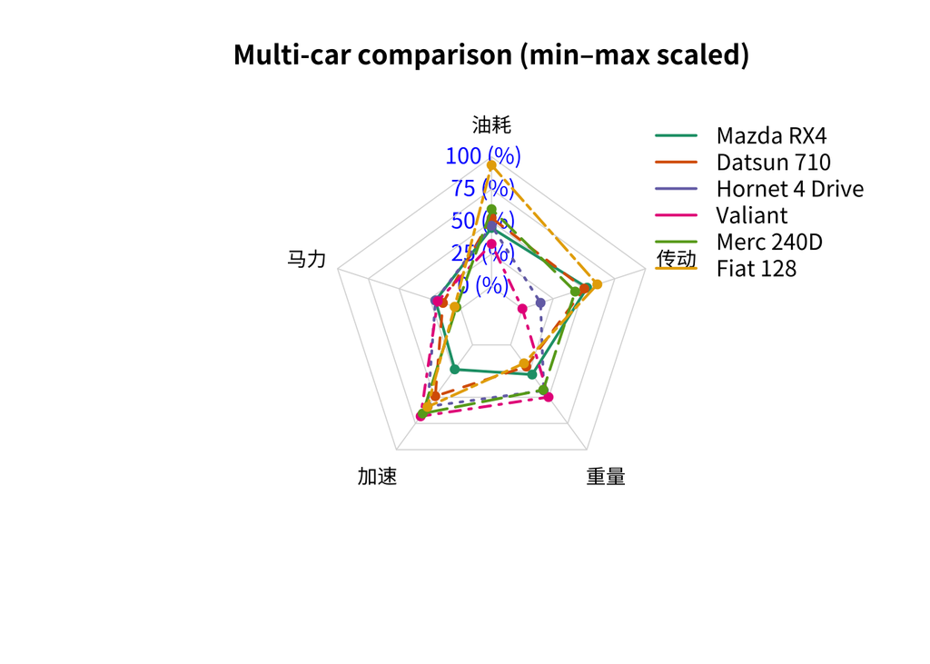

```r
# ==============================================================================
# 进阶：多车同图对比 + 单车小多图（2×3）— fmsb 版本
#   - 同图叠加：快速比较“结构差异”
#   - 小多图：逐一阅读每辆车的多维画像（统一尺度）
# ==============================================================================

library(tidyverse)
library(fmsb)
library(showtext)
library(sysfonts)

# -----------------------------
# 0) 环境准备（含字体：可跨平台稳定显示中文）
# -----------------------------
font_add_google(name = "Noto Sans SC", family = "my_font")
showtext_auto()
options(scipen = 9999)

# ==============================================================================
# 1) 参数设置：车型集合 + 指标维度 + 中文轴标签
# ==============================================================================
cars_sel <- c("Mazda RX4", "Datsun 710", "Hornet 4 Drive",
              "Valiant", "Merc 240D", "Fiat 128")

vars    <- c("mpg", "hp", "qsec", "wt", "drat")      # 计算用英文变量名
vars_zh <- c("油耗", "马力", "加速", "重量", "传动")  # 显示用中文维度名

# ==============================================================================
# 2) 数据准备：按维度做 min–max 标准化（缩放到 [0,1]）
# ==============================================================================
df_scaled <- mtcars %>%
  rownames_to_column("car") %>%
  select(car, all_of(vars)) %>%
  pivot_longer(-car, names_to = "var", values_to = "raw") %>%
  group_by(var) %>%
  mutate(score = (raw - min(raw, na.rm = TRUE)) / (max(raw, na.rm = TRUE) - min(raw, na.rm = TRUE))) %>%
  ungroup() %>%
  filter(car %in% cars_sel) %>%
  mutate(var = factor(var, levels = vars))

# ==============================================================================
# 3) 转换为 fmsb 输入：宽表 + 上界/下界两行（固定坐标尺度）
# ==============================================================================
df_wide <- df_scaled %>%
  select(car, var, score) %>%
  pivot_wider(names_from = var, values_from = score) %>%
  column_to_rownames("car") %>%
  as.data.frame()

radar_all <- rbind(
  rep(1, length(vars)),
  rep(0, length(vars)),
  df_wide
)
colnames(radar_all) <- vars_zh

# ==============================================================================
# 4) 配色：线色 + 透明填充（分图使用）
# ==============================================================================
cols_line <- RColorBrewer::brewer.pal(n = length(cars_sel), name = "Dark2")
cols_fill <- scales::alpha(cols_line, 0.25)

# ==============================================================================
# 5) 总图：多车叠加（仅画轮廓线；避免填充造成遮挡）
# ==============================================================================
op <- par(family = "my_font")

fmsb::radarchart(
  radar_all,
  pcol  = cols_line,
  pfcol = NA,
  plwd  = 2,
  axistype = 1,
  cglcol = "grey85",
  cglty  = 1,
  cglwd  = 0.8,
  vlcex  = 0.9
)
title(main = "Multi-car comparison (min–max scaled)")

legend(
  "topright",
  legend = rownames(df_wide),
  bty = "n",
  col = cols_line,
  lwd = 2
)
```

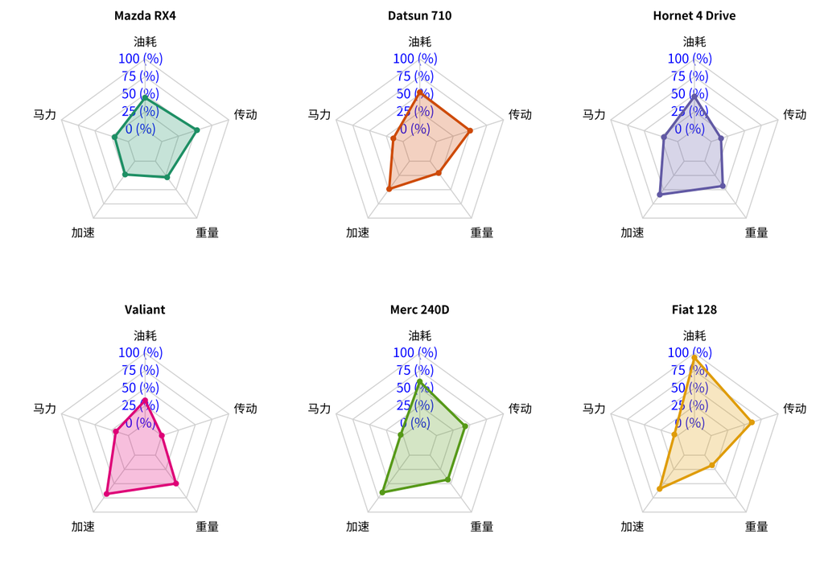

```r
# ==============================================================================
# 6) 分图：单车雷达图（2×3 小多图；启用透明填充）
# ==============================================================================
par(mfrow = c(2, 3), mar = c(2, 2, 2, 1))

for (i in seq_along(cars_sel)) {
  car_i <- cars_sel[i]

  radar_one <- rbind(
    rep(1, length(vars)),
    rep(0, length(vars)),
    df_wide[car_i, , drop = FALSE]
  )
  colnames(radar_one) <- vars_zh

  fmsb::radarchart(
    radar_one,
    pcol  = cols_line[i],
    pfcol = cols_fill[i],
    plwd  = 2,
    axistype = 1,
    cglcol = "grey85",
    cglty  = 1,
    cglwd  = 0.8,
    vlcex  = 0.9
  )

  title(main = car_i, cex.main = 0.9)
}
```